European Neuropsychopharmacology 51 (2021) 106–131

[figure not shown]

[figure not shown]

www.elsevier.com/locate/euroneuro

[figure not shown]

**Co-exposure** **of** **cocaine** **and** **cannabinoids**

**and** **its** **association** **with** **select** **biological,**

**behavioural** **and** **health** **outcomes:** **A**

**systematic** **scoping** **review** **of**

**multi-disciplinary** **studies**

**Dimitri** **Daldegan-Bueno** <sup>**a**</sup>**,** **Lucas** **O.** **Maia** <sup>**b**</sup>**,** **Michelle** **Glass** <sup>**c**</sup>**,**

**Didier** **Jutras-Aswad** <sup>**d**</sup><sup>**,**</sup><sup>**e**</sup>**,** **Benedikt** **Fischer** <sup>**a**</sup><sup>**,**</sup><sup>**b**</sup><sup>**,**</sup><sup>**f**</sup><sup>**,**</sup><sup>**g**</sup><sup>**,**</sup><sup>**∗**</sup>

a *Schools* *of* *Population* *Health* *and* *Pharmacy,* *Faculty* *of* *Medical* *and* *Health* *Sciences,* *University* *of*

*Auckland,* *Auckland,* *New* *Zealand*

b *Centre* *for* *Applied* *Research* *in* *Mental* *Health* *&* *Addiction,* *Simon* *Fraser* *University,* *Vancouver,* *Canada*

c *Department* *of* *Pharmacology* *and* *Toxicology,* *University* *of* *Otago,* *Otago,* *New* *Zealand*

d *Centre* *de* *Recherche,* *Centre* *Hospitalier* *Universitaire* *de* *Universite* *de* *Montreal* *(CHUM),* *Montreal,*

*Canada*

e *Department* *of* *Psychiatry* *and* *Addiction,* *Faculty* *of* *Medicine,* *Université de* *Montréal,* *Montreal,*

*Canada*

f *Department* *of* *Psychiatry,* *University* *of* *Toronto,* *Toronto,* *Canada*

g *Department* *of* *Psychiatry,* *Federal* *University* *of* *Sao* *Paulo* *(UNIFESP),* *Sao* *Paulo,* *Brazil*

Received 26 March 2021; received in revised form 3 June 2021; accepted 7 June 2021

*List* *of* *abbreviations:* AOR, adjusted odds ratio; BF, Bayes factor; BNDF, brain-derived neurotrophic factor; BOLD, blood-oxygen-level-

dependent; CBD, cannabidiol; CBI, credible intervals; CB1R, cannabinoid receptor type 1; CI, conﬁdence interval; DAT, dopamine active

transporter; DSM, Diagnostic and Statistical Manual of Mental Disorders; ERK1/2, Extracellular signal–regulated kinases 1/2; HIV, human

immunodeﬁciency virus; HR, hazard ratio; i.p., intraperitoneal; i.v., intravenous; MeSH, Medical Subject Headings; NeuN/BrdU + , Neuronal

Nuclei/5-bromo-2 <sup>′</sup>-deoxyuridine; OR, odds ratio; RCT, randomised controlled trial; RMSEA, root-mean-square error of approximation; PRESS,

Peer Review Electronic Search Strategies; PTSD, post-traumatic stress disorder; RR, risk ratio; s.c., subcutaneous; SRA-DM, The Systematic

Review Assistant-Deduplication Module; SRMR, root-mean-square residual; TH, tyrosine hydroxylase; THC, tetrahydrocannabinol; US, United

States; 5-HT, 5-Hydroxytryptamine (serotonin).

∗ Corresponding author at: Faculty of Medical and Health Sciences, University of Auckland, 85 Park Rd, Grafton, Auckland 1023, New

Zealand.

*E-mail* *address:* bﬁscher@sfu.ca (B. Fischer).

https://doi.org/10.1016/j.euroneuro.2021.06.002

0924-977X/ © 2021 The Author(s). Published by Elsevier B.V. This is an open access article under the CC BY-NC-ND license

( http://creativecommons.org/licenses/by-nc-nd/4.0/ )

European Neuropsychopharmacology 51 (2021) 106–131

**KEYWORDS**

Cocaine;

Cannabis;

Cannabinoids;

Addictive behavior;

Translational research;

Review

**Abstract**

Cocaine use entails severe health- and social-related harms globally. Treatment options for

cocaine dependence are highly limited. Beneﬁts of cannabinoids for addiction have been doc-

umented, making it opportune to examine existing data on the possible outcomes associated

with cannabinoids and cocaine co-use. We conducted a systematic scoping review following

the PRISMA guidelines of peer-reviewed, English-language studies published from 2000 to 2021

in four databases (Medline, Web-of-Science, CINAHL Plus, and PsycInfo), assessing the co-

exposure of cannabis/cannabinoids with cocaine on behavioural, biological or health outcomes.

Both quantitative and qualitative, as well as humans and pre-clinical animals’ studies (n = 46)

were included. Pre-clinical studies (n = 19) showed mostly protective effects of cannabidiol

(CBD) administration on animal models of addiction (e.g., cocaine-craving, -relapse, and -

withdrawal) and cocaine-toxicity. Tetrahydrocannabinol (THC) had more inconsistent results,

with both protective and counter-protective effects. Human studies (n = 27) were more hetero-

geneous and assessed natural ongoing cannabis and cocaine use or dependence. Quantitative-

based studies showed mostly enhanced harms in several outcomes (e.g., cocaine use, men-

tal health); two available clinical trials found no effect upon CBD administration on cocaine-

related treatment outcomes. Qualitative data-based studies reported cannabis use as a sub-

stitute for or to alleviate harms of crack-cocaine use. While pre-clinical studies suggest a po-

tential of cannabinoids, especially CBD, to treat cocaine addiction, the few trials conducted

in humans found no beneﬁts. Cannabis co-use by cocaine users commonly presents a risk fac-

tor, entailing enhanced harms for users. More rigorous, controlled trials are still necessary to

investigate cannabinoids’ potential considering pre-clinical ﬁndings and reported beneﬁts from

speciﬁc drug users.

© 2021 The Author(s). Published by Elsevier B.V. This is an open access article under the CC

BY-NC-ND license ( http://creativecommons.org/licenses/by-nc-nd/4.0/ )

**1.** **Introduction**

Estimates suggest that some 0.4% (approximately 19 million

people) of the world’s adult population use cocaine, with

some 3.9 million people cocaine dependent in 2015, ren-

dering cocaine products to be among the most widely used

illicit drugs globally ( Degenhardt et al., 2013 ; Peacock et

al., 2018 ; UNODC, 2020 ). Use of cocaine – particularly in

distinct regions and/or user populations – occurs in a vari-

ety of different forms and formulations (e.g., cocaine pow-

der and crack-cocaine), involving different use modes, such

as inhalation, smoking or injection ( Fischer et al., 2013 ;

Goldstein et al., 2009 ; Warner, 1993 ). Cocaine use is asso-

ciated with elevated risks for multiple morbidity and mor-

tality outcomes involving cardiovascular and infectious dis-

eases, mental health problems (e.g., depression, psychosis,

suicide) and violence ( Afonso et al., 2007 ; Butler et al.,

2017 ; Dackis and O’Brien, 2001 ; Ford et al., 2009 ). Cocaine

users’ mortality risk is multi-fold higher than that of the

general population ( Degenhardt et al., 2011 ). In 2017, an

estimated 0.3% (approximately 178,000 people) of global

all-cause mortality was associated with cocaine dependence

( Farrell et al., 2019 ). Commonly, people who use psychos-

timulants, including cocaine, also co-use multiple other psy-

choactive drugs (e.g., opioids), amplifying risks for adverse

health outcomes, such as overdose risk and mortality ( Cofﬁn

et al., 2003 ; Kohut, 2017 ; Leri et al., 2003 ; Motta-Ochoa et

al., 2017 ). Recent changes in illegal drug production, espe-

cially with substantive expansion in cocaine manufacturing

in Latin America, suggest that cocaine supply/use have been

increasing globally ( UNODC, 2020 ).

Currently, no pharmaco-therapies have been approved

for any of the main stages of treatment for cocaine (or

other psychostimulants) use disorder (e.g., risk reduction,

targeted prevention for use or intoxication, withdrawal or

abstinence-oriented treatment, relapse prevention) ( Farrell

et al., 2019 ; Fischer et al., 2015b ). In addition, the appli-

cation range and outcomes of psychosocial (e.g., targeted

prevention or treatment) interventions for cocaine use

are overall highly limited, with mainly selected cognitive-

behavioural interventions, including contingency manage-

ment approaches, showing some positive effects ( Knapp

et al., 2007 ; Minozzi et al., 2016 ; Penberthy et al., 2010 ;

Schierenberg et al., 2012 ; Shearer, 2007 ). This underscores

the need for examination of putative therapeutic strate-

gies for psychostimulant use, and speciﬁcally problematic

cocaine use or cocaine use disorders ( Fischer et al., 2015a ;

Fischer et al., 2015b ; Kogan and Mechoulam, 2007 ; Shorter

et al., 2015 ). Cannabinoids have emerged as one potential

therapeutic avenue for addictive disorder and speciﬁcally

stimulant-related adverse effects; they are increasingly ac-

cessible for therapeutic usage through ‘medical cannabis’

provisions in different jurisdictions ( Abrams, 2018 ; Crippa

et al., 2018 ; Hill, 2015 ; NASEM, 2017 ; Rodrigues et al.,

2020 ; Walsh et al., 2017 ). Cannabis products are widely

used around the world for both ‘non-medical’ and ‘medical’

purposes. More generally, the non-medical use of cannabis

is associated with risk for a variety of adverse health out-

comes, including acute and chronic neuro-cognitive impair-

ment, mental health problems (e.g., psychosis, depression,

suicide), cannabis use disorder (dependence), injuries (e.g.,

related to cannabis-impaired driving), and select others

( Hall et al., 2019 ; Hasan et al., 2020 ; Lorenzetti et al.,

2020 ; Memedovich et al., 2018 ; Scott et al., 2018 ; Volkow

et al., 2014 ). The risks for these adverse outcomes are sub-

stantially elevated for use at young age, and frequent use

involving high-potency (THC) products ( Fischer et al., 2017 ;

Hines et al., 2020 ; Kiburi et al., 2021 ; Leung et al., 2021 )

Notwithstanding the aforementioned cannabis use-

related risks, there has been growing interest in the endo-

cannabinoid system as a possible target for treating craving

and addiction ( Manzanares et al., 2018 ; Parsons and Hurd,

2015 ; Spanagel, 2020 ). Notably, different cannabinoids that

target the endocannabinoid system exhibit distinct prop-

erties on addictive behaviour. Most studies have focused

on *�*<sup>9</sup>-tetrahydrocannabinol (THC), the principal psychoac-

tive constituent of the *cannabis* plant, as the compound

that drives the rewarding effects of cannabis through ac-

tivation of central nervous system CB 1 receptors ( Spanagel,

2020 ). Blockade of this receptor through antagonists have

been proposed for the treatment of substance use disor-

der ( Manzanares et al., 2018 ; Robinson et al., 2018 ; Soyka

et al., 2008 ). Recently, interest has focused on cannabid-

iol (CBD), a non-intoxicating phyto-cannabinoid, based on

evidence that CBD may act as an inverse agonist or neg-

ative allosteric modulator of CB 1 receptors ( Ibeas Bih et

al., 2015 ; Laprairie, Bagher, Kelly, and Denovan-Wright,

2015 ; Spanagel, 2020 ). Other potential targets of CBD

have been identiﬁed, including transient receptor poten-

tial vanilloid 1/2 proteins, fatty acid amide hydrolase (a

hydrolysing enzyme of the endogenous cannabinoid anan-

damide) and 5-hydroxytryptamine (5-HT) 1A serotoninergic

receptors ( Parsons and Hurd, 2015 ). Furthermore, user self-

reports have described the intentional use of cannabinoids

to modulate psycho-stimulant (e.g., crack-cocaine) use or

adverse effects. On this basis, beneﬁcial properties or ef-

fects from cannabinoids may exist for addictive behaviours

related to a range of different psychoactive substance cat-

egories (e.g., opioids, nicotine, alcohol) yet speciﬁcally for

psychostimulants ( Abrams, 2018 ; Calpe-López et al., 2019 ;

Fischer et al., 2015b ; Prud’homme et al., 2015 ).

Given the overall substantial use prevalence of and harms

related to cocaine use, and the general lack of effective

therapeutic interventions, we sought to systematically ex-

amine and review existing, multi-disciplinary data on possi-

ble associations of cannabinoid use or exposure on cocaine

use and adverse outcomes from animal (e.g., pre-clinical)

as well as human (e.g., clinical, epidemiological, observa-

tional) study populations.

**2.** **Methods**

**2.1.** **Study** **aims** **and** **scope**

The review’s principal objective was to systematically identify and

summarize data on the effects and associations of experimental or

natural co-use of cannabinoids on cocaine use-related biological,

behavioural, and health outcomes from different methodological or

disciplinary studies (e.g., pre-clinical, human experimental, obser-

vational approaches). Considering the marked diversity and hetero-

geneity of available studies, and their methods and outcome data,

we conducted a systematic scoping review, as indicated appropri-

ate for such a review approach and landscape of evidence ( Peters

et al., 2015 ). The review adhered to essential steps and procedures

for a systematic review, including a structured search strategy and

reporting, following the PRISMA guidelines ( Munn et al., 2018 ; Page

et al., 2021 ; Tricco et al., 2018 ). We considered cannabinoids as all-

natural cannabis product forms or compositions (e.g., THC, CBD)

and cocaine as any cocaine-based product (e.g., crack-cocaine),

regardless of mode of use (e.g., smoking, ingestion), subject sta-

tus (e.g., dependence) or intended purpose of use (e.g., medical,

non-medical).

**2.2.** **Search** **strategy**

The systematic search strategy focused on cannabis/cannabinoid-

and cocaine-related words and MeSH terms related to cannabinoids,

cannabis and cocaine. The full search strategy details for the dif-

ferent databases searched are available as supplementary material

( Supplementary Material 1 & 2 ). The search strategy was developed

for MEDLINE through an interactive process by the co-authors, re-

vised using the Peer Review Electronic Search Strategies (PRESS)

checklist ( McGowan et al., 2016 ) and adjusted for application

in other databases. The following four databases were accessed:

MEDLINE (PubMed), Web of Science (core collection), CINAHL plus

and PsycInfo. The results were collated and de-duplicated using

The Systematic Review Assistant-Deduplication Module (SRA-DM)

( Rathbone et al., 2015 ) and then uploaded to Endnote (v.X9.2),

where all screening and management tasks were performed. Com-

plementary search strategies included manual searching of refer-

ence lists of included studies.

**2.3.** **Study** **selection**

Screening and studies selection involved the following inclusion

criteria: 1) original studies based on primary study data; 2) stud-

ies explicitly examining the co-use or co-exposure of cannabi-

noid products with cocaine products in human or animal model

populations; 3) reporting biological, behavioural or health-related

measures or outcomes (e.g., brain activity/function, craving, drug

use/dependence); 4) with measures or outcomes that compara-

tively addressed cocaine-only and cocaine and cannabinoid co-use

or -exposure; 5) studies in English-language published from 2000

to 9 February 2021. Given the aim of a comprehensive, multi-

disciplinary scoping review, both quantitative and qualitative stud-

ies were included. We excluded studies not meeting the above cri-

teria, as well as reviews, commentaries, case reports and case-

control studies with other non-target drug use (e.g., comparing

cocaine to alcohol and cannabis). Moreover, studies with speciﬁc

other disease populations (e.g., HIV-positive, PTSD sample) were

excluded.

Following de-duplication, titles and abstracts were screened

by one lead reviewer (DDB), with potentially unclear or ambigu-

ous cases arbitrated towards consensus together with a second

reviewer. Then, full-text review of studies for possible inclusion

was performed by the same procedure. Studies excluded predom-

inantly did not match the content or outcome speciﬁc criteria for

the review (e.g., no clear cannabis/cocaine comparison, no cur-

rent cannabis use). In accordance with systematic review principles

( Page et al., 2021 ), the attached PRISMA-based ﬂowchart ( Fig. 1 )

reports the review’s main process steps and outcome information.

European Neuropsychopharmacology 51 (2021) 106–131

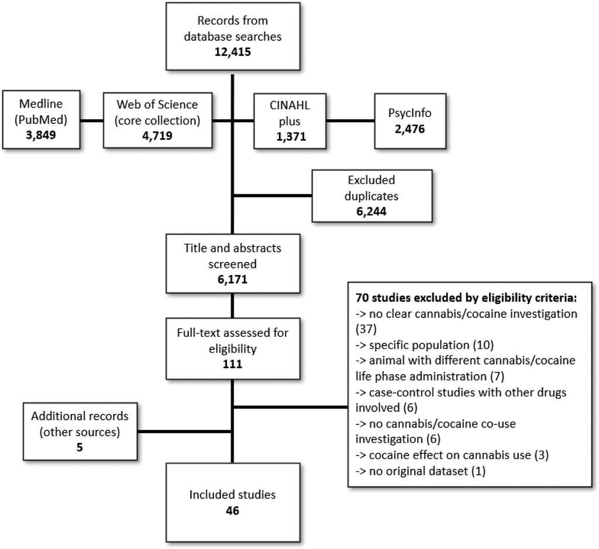

**Fig.** **1** Flowchart of the selection process of studies.

**2.4.** **Data** **synthesis**

Data was extracted by the lead author (DDB). For results documen-

tation, we inductively grouped the included studies by study design

or outcome characteristics, further dividing them into study sub-

cluster, and narratively summarized the individual studies’ scopes,

measures and results. No risk of bias or quality assessment and no

meta-analysis were conducted (also due to the heterogeneity of in-

dividual study designs and outcomes), as is common for a scoping

review ( Arksey and O’Malley, 2005 ).

**3.** **Results**

**3.1.** **Characteristics** **of** **included** **studies**

Overall, 12,415 article citations were identiﬁed from the

database searches, which, after de-duplication, resulted in

a total of 6,171 potentially relevant abstracts screened.

secondary searches, were included in the present review

( Fig. 1 ). Thirty-four (74%) of the studies were published

from 2010 onward. Articles were broadly divided into

studies with animal experimental models (n = 19) and hu-

man populations (n = 27). Animal studies mostly involved

rodent- (i.e., rats and mice), but also monkey-based an-

imal experiments with CBD or THC administration com-

pared to controls (i.e., vehicle administration) divided into

three clusters: non-contingent animal models of addiction

(e.g., conditioned place-preference and sensitization ex-

periments) (n = 7), contingent models of addiction (drug

self-administration or brain self-stimulation experiments)

(n = 8), and cocaine pharmacokinetics and induced toxic-

ity (n = 4). Human subject studies were more heteroge-

neous involving addiction treatment, hospitalisation, and

community-based epidemiologic studies, speciﬁcally con-

sisting of clinical or case-control, longitudinal, cohort, or

observational studies assessing several outcomes (e.g., co-

D. Daldegan-Bueno, L.O. Maia, M. Glass et al.

caine use and treatment outcomes, neurocognitive func-

tions, mental health) based on biological, quantitative or

qualitative measures; therefore, topically divided into co-

caine use behaviours (n = 11), cannabis-based risk-reduction

for cocaine (n = 12), and health and miscellaneous outcomes

(n = 4). Key methods and results details of all studies in-

cluded are presented in Tables 1 and 2 .

**3.2.** **Animal/pre-clinical** **studies** **(see** **Tables** **1** **for**

**study** **and** **results** **details)**

**3.2.1.** **Non-contingent** **models** **of** **addiction** **(n** **=** **7)**

conditioning place preference paradigms in rodents (n = 8–

15/group). Single CBD (10 mg/kg, s.c.) administration

immediately after cocaine-paired memory reactivation

decreased cocaine-conditioned memory reconsolidation

(F[1,60] = 5.38, p *<* 0.01, post-hoc p *<* 0.05) ( de Carvalho and

Takahashi, 2017 ). Single CBD (30 and 60 mg/kg, i.p.) ad-

ministration 60 minutes before pharmacological- (cocaine,

5 mg/kg, i.p.) or stress-induced (social defeat) cocaine-

reinstatement prevented, at both dose-levels, both mech-

anisms of cocaine-reinstatement (F[9,117] = 2.300, p *<* 0.02;

(F[3,40] = 9.347, p *<* 0.001, post-hoc p *<* 0.05; CBD alone did

not reinstate cocaine-induced place preference (p = 1.00)

( Calpe-López et al., 2021 ). CBD (10 mg/kg, i.p.) administra-

tion immediately after cocaine condition sessions or 30 min-

utes before cocaine-induced reinstatement or conditioning

and extinction sessions reduced preference for a cocaine-

paired context 20 days after CBD cessation (F[3,48] = 4.1,

p = 0.01, post-hoc p *<* 0.05) and reduced cocaine memory

consolidation (F[5,140] = 3.2, p = 0.001, post-hoc p *<* 0.05)

but did not affect cocaine-related memory reconsolida-

tion, extinction and reinstatement (F[4,88] = 0.1, p = 0.9;

F[5,80] = 0.9, p = 0.5; F[1,16] = 0.1, p = 0.9) ( Chesworth and

Karl, 2020 ). Moreover, single CBD (5 mg/kg, i.p.) or

THC (0.5 mg/kg, i.p.) administration 30 minutes before

the extinction of cocaine-induced place-preference con-

ditioning potentiated the extinction of cocaine-induced

place-preference learning (F[3,76] = 4.6, p *<* 0.01, post-hoc

p *<* 0.05) ( Parker et al., 2004 ).

Three studies using rodents investigated the effects

of CBD (10–40 mg/kg, i.p.) or THC (3, 10 mg/kg, i.p.)

on cocaine-induced sensitization (n = 8–16/group). Single

CBD (10, 20, and 40 mg/kg, i.p.) administration 90 min-

utes before an induced model of cocaine withdrawal

(15–60 mg/kg, i.p., 12-days of increasing doses) blocked,

at all doses, cocaine-induced hyperlocomotion and anxi-

ety (F[4,48] = 4.173, p = 0.006; F[4,48] = 12.573, p *<* 0.001).

At different doses, CBD normalized somatic withdrawal

behaviours (e.g., increased rearing, digging, rubbings)

(F[4,48] = 4.589–15.025, all p *<* 0.005) and reduced cocaine-

induced DAT and TH gene expression in the ventral tegmen-

tal area (F[4,47] = 5.019, p *<* 0.01; F[4,42] = 4.878, p *<* 0.01)

( Gasparyan et al., 2020 ). Daily THC (3 mg/kg, i.p.) admin-

istration for eight days before cocaine administration (1–

30 mg/kg, i.p.) increased cocaine-induced locomotor activ-

ity in adolescent rats while decreasing locomotor activity

in adults (F[4,232] = 3.38, p ≤0.01; F[1,52] = 5.75, p ≤0.02,

post-hoc p *<* 0.001) ( Dow-Edwards and Izenwasser, 2012 ).

Daily THC with/without CBD (each 10 mg/kg, i.p.) ad-

ministration for ﬁve days, 30 minutes before daily co-

caine administration (15 mg/kg, i.p.) did not affect cocaine-

sensitization (F[1,56] = 0.03, p = 0.8) and locomotor activity

after a drug-free period (p *>* 0.05) ( Gerdeman et al., 2008 ).

**3.2.2.** **Contingent** **models** **of** **addiction** **(n** **=** **8)**

Eight studies investigated the effect of CBD (3–40 mg/kg)

monkeys trained to self-administrate cocaine (0.03–

0.75 mg/kg/infusion, i.v.) or to self-stimulate intracranially

(n = 4–33/group). Single CBD (20 mg/kg, i.p.) administration

before cocaine self-administration acquisition sessions

reduced cocaine consumption and cocaine-paired compart-

ment preference (t[71] = 2.00, p = 0,049; F[4,176] = 5.71,

p = 0.001, post-hoc p *<* 0.001), but daily CBD administra-

tion for ten days (5, 10, 20 and 30 mg/kg, i.p.) before

cocaine-sensitization and place preference conditioning

(10 mg/kg, i.p) had no effect on cocaine-sensitization and

-reinstatement (F[1,44] = 0.34, p = 0.558; F[1,15] = 7.51,

p = 0.015, post-hoc p *>* 0.05). Hippocampal molecular mark-

ers (e.g., CB1R, ERK1/2, BDNF, p *<* 0.05) were higher in

CBD-treated animals ( Luján et al., 2018 ). Single CBD (3,

10, 20, 40 mg/kg, i.p.) administration 30 minutes be-

fore cocaine self-administration test dose-dependently

(10–40 mg/kg) inhibited low-doses (0.03–0.12 mg/kg) of

cocaine self-administration (F[10,120] = 2.33, p *<* 0.05, post-

hoc p *<* 0.05), and diminished cocaine self-administration

break-points under a progressive-ratio schedule of rein-

forcement (F[2,20] = 6.25; p *<* 0.01, post-hoc p *<* 0.05). When

administered 30 minutes before cocaine (2 or 10 mg/kg,

i.p.), CBD (3–20 mg/kg) attenuated cocaine-enhanced

brain-stimulation reward and cocaine-induced increases of

dopamine in the nucleus accumbens in a dose-dependent

manner

(F[3,30] = 3.17;

p *<* 0.05,

post-hoc

p *<* 0.05;

F[14,147] = 4.28, p *<* 0.001, post-hoc p *<* 0.001) ( Galaj et

al., 2020 ). Single CBD (5 and 10 mg/kg, i.p.) administration

30 minutes and 24 hours before cocaine self-administration

test or before cocaine-reinstatement test had no effect

on cocaine self-administration under a progressive ratio

schedule of reinforcement (F[1.87,16.88] = 0.31, p = 0.82;

F[1.93,17.37] = 0.53, p = 0.59), nor on cocaine-seeking

and cue-induced cocaine-reinstatement after 14 with-

drawal days (F[2,7] = 2.31, p = 0.17; F[2,14] = 0.59, p = 0.57)

( Mahmud et al., 2017 ). Single CBD (5 mg/kg, i.p.) admin-

istration after intracranial self-stimulation learning and

20 minutes before cocaine (5 mg/kg, i.p.) administration

had no impact on the reward-facilitating effects of cocaine

(p *>* 0.05) ( Katsidoni et al., 2013 ). CBD (20 mg/kg, i.p.) ad-

ministration daily for ten days, immediately before cocaine

self-administration acquisition learning sessions reduced co-

caine self-administration acquisition (x2 = 18.1, p *<* 0.001),

intake (F[1,36] = 13.74, p *<* 0.001) and increased the number

of NeuN/BrdU + cells and neurogenesis in the hippocampus

(F[1,13] = 47.87, p *<* 0.001; F[1,12] = 4.75, p *<* 0.05) ( Luján

et al., 2020 ). Daily CBD (15 mg/kg, transdermal) admin-

istration for seven days after cocaine self-administration

extinction attenuated context- and pharmacological

stress-induced cocaine-seeking (F[1,20] = 8.93, p *<* 0.01;

F[1,19] = 11.71, p *<* 001, post-hoc p *<* 0.05), and reduced

European Neuropsychopharmacology 51 (2021) 106–131

**Table** **1**

Animal pre-clinical studies with cannabinoids and cocaine co-administration.

Authors

Sample

(sample size)

Cannabinoid

Intervention/Design

Outcome

measures

Pattern of

cannabinoid

administration

Main results

**Non-contingent** **models** **of** **addiction**

Calpe-López,

Gasparyan,

Navarrete et

al., 2021

Mice

(12/group)

CBD

30 and

60 mg/kg,

i.p.

Effects of CBD on

drug- and

stress-induced

cocaine

reinstatement

(vehicle-

controlled

study)

CBD-, cocaine-

and social

defeat-induced

reinstatement

of cocaine-

induced place

preference;

DAT gene in the

ventral

tegmental area

Single CBD dose

60 min before

cocaine- or social

defeat-induced

reinstatement

↑ CBD prevented cocaine-

and stress- induced

cocaine-reinstatement

(F[9,117] = 2.300, p *<* 0.02;

F[9,99] = 2.005, p *<* 0.05) and

cocaine-induced DAT gene

increase in the ventral

tegmental area

(F[3,40] = 9.347, p *<* 0.001)

Chesworth and

Karl, 2020

Mice

(9–15/group)

CBD

10 mg/kg,

i.p.

Effects of CBD on

cocaine-

environment

memory (vehicle-

controlled

study)

Cocaine-place

preference

acquisition,

consolidation,

reconsolida-

tion, extinction

and cocaine-

induced

reinstatement

Single CBD dose

right after cocaine

place preference

conditioning

sessions or 30 min

before

cocaine-induced

cocaine-

reinstatement or

conditioning and

extinction sessions

↑ CBD reduced preference

for a cocaine-paired

environment and reduced

cocaine memory

consolidation (F[3,48] = 4.1,

p = 0.01; F[5,140] = 3.2,

p = 0.001), but did not affect

cocaine memory

reconsolidation, extinction

or reinstatement

(F[4,88] = 0.1, p = 0.9;

F[5,80] = 0.9, p = 0.5;

F[1,16] = 0.1, p = 0.9).

Gasparyan,

Navarrete,

Rodríguez-Arias

et al., 2020

Mice

(8–10/group)

CBD

10, 20,

40 mg/kg,

i.p.

Effect of CBD on

cocaine-

withdrawal

(vehicle-

controlled

study)

Cocaine-

induced

hyperlocomo-

tion, anxiety,

and withdrawal

behaviours;

DAT and TH

gene

expression in

the ventral

tegmental area

Single CBD dose

six hours after

increasing daily

cocaine

administration and

90 min before

tests

↑ CBD at all doses blocked

cocaine-induced

hyperlocomotion and

anxiety (F[4,48] = 4.173,

p = 0.006; F[4,48] = 12.573,

p *<* 0.001), at different

doses normalized

withdrawal behaviours

(F[4,48] = 4.589–15.025, all

p *<* 0.005) and reduced

cocaine-induced DAT and TH

expression (F[4,47] = 5.019,

p *<* 0.01; F[4,42] = 4.878,

p *<* 0.01)

( *continued* *on* *next* *page* )

111

D. Daldegan-Bueno, L.O. Maia, M. Glass et al.

**Table** **1**

( *continued* )

Authors

Sample

(sample size)

Cannabinoid

Intervention/Design

Outcome

measures

Pattern of

cannabinoid

administration

Main results

de Carvalho

and Takahashi,

2017

Rats

(10/group)

CBD

10 mg/kg,

s.c.

Effects of CBD on

the

reconsolidation of

cocaine-

environment

memory (vehicle-

controlled

study)

Cocaine place

preference

memory

reconsolidation

Single CBD dose

immediately after

the reactivation of

cocaine-paired

place preference

memory

↑ CBD decreased

reconsolidation of

cocaine-paired place

preference (F[1,60] = 5.38,

p *<* 0.01)

Dow-Edwards

and Izenwasser,

2012

Rats

(14–16/group)

THC

3 mg/kg,

i.p.

Effects of THC on

cocaine-

stimulated activity

in different ages

(vehicle-

controlled

study)

Cocaine

sensitization in

adolescent and

adult rats;

locomotor

activity

Daily THC dose for

eight days,

followed by

cocaine

administration

after four

drug-free days

↓ THC increased

cocaine-sensitization in

adolescents and decreased

locomotor activity in adult

rats (F[4,232] = 3.38,

p ≤0.01; F[1,52] = 5.75,

p ≤0.02)

Gerdeman,

Schechter, and

French, 2008

Mice

(9–10/group)

THC

with/without

CBD,

10 mg/kg

each, i.p.

Effects of THC

with/without CBD

on cocaine-

sensitization

(vehicle-

controlled

study)

Cocaine

sensitization;

locomotor

activity

Daily THC or

THC + CBD dose,

30 min before

daily cocaine

administration for

ﬁve days, except

for the ﬁrst and

last day

↔ CBD alone or combined

with THC had no effect on

cocaine-sensitization

(F[1,56] = 0.03, p = 0.8) or

locomotor activity (p *>* 0.05)

Parker, Burton,

Sorge et al.,

2004

Rats

(8–12/group)

CBD

(5 mg/kg)

or THC

(0.5 mg/kg),

i.p.

Effects of CBD or

THC on cocaine-

environment

memory extinction

(vehicle-

controlled

study)

Extinction of

cocaine-

induced place

preference

Single CBD or THC

dose 30 min before

cocaine-induced

place preference

extinction trial

↑ CBD and THC potentiated

the extinction of

cocaine-induced

place-preference learning

(F[3,76] = 4.6, p *<* 0.01)

( *continued* *on* *next* *page* )

112

European Neuropsychopharmacology 51 (2021) 106–131

**Table** **1**

( *continued* )

Authors

Sample

(sample size)

Cannabinoid

Intervention/Design

Outcome

measures

Pattern of

cannabinoid

administration

Main results

**Contingent** **models** **of** **addiction**

Galaj, Bi, Yang

et al., 2020

Rats

(6–12/group)

CBD

3, 10, 20,

40 mg/kg,

i.p.

Effects of CBD on

cocaine reward

effects (vehicle-

controlled

study)

Cocaine self-

administration;

brain-

stimulation

reward;

dopamine

levels in the

nucleus

accumbens

Single CDB dose

30 min before

cocaine self-

administration

tests or 30 min

before cocaine

administration

↑ CBD attenuated

cocaine-enhanced

brain-stimulation reward,

dose-dependently inhibited

low doses of cocaine

self-administration

(F[3,30] = 3.17; p *<* 0.05;

F[10,120] = 2.33, p *<* 0.05),

lowered cocaine

self-administration

break-points and

attenuated cocaine-induced

increases of dopamine

(F[2,20] = 6.25; p *<* 0.01;

F[14,147] = 4.28, p *<* 0.001)

Luján,

Cantacorps and

Valverde, 2020

Mice

(10/group)

CBD

20 mg/kg,

i.p.

Effects of CBD on

cocaine-intake

(vehicle-

controlled

study)

Cocaine self-

administration

and molecular

markers in the

hippocampus

dentate gyrus

Single CBD dose

before each

cocaine self-

administration

acquisition

sessions

↑ CBD reduced cocaine

self-administration

acquisition (x2 = 18.1,

p *<* 0.001), intake

(F[1,36] = 13.74, p *<* 0.001)

and increased the number

of NeuN/BrdU+ cells and

neurogenesis in the

hippocampus

(F[1,13] = 47.87, p *<* 0.001;

F[1,12] = 4.75, p *<* 0.05)

( *continued* *on* *next* *page* )

113

D. Daldegan-Bueno, L.O. Maia, M. Glass et al.

**Table** **1**

( *continued* )

Authors

Sample

(sample size)

Cannabinoid

Intervention/Design

Outcome

measures

Pattern of

cannabinoid

administration

Main results

John, Martin

and Nader,

2020

Monkeys

(4)

THC

0 ∗, 0.03,

0.1,

0.3 mg/kg,

i.v.

Effects of THC on

cocaine self-

administration

within a food-drug

choice paradigm

(vehicle-

controlled

study)

Cocaine

choice, cocaine

injections, food

reinforcers

earned and

total

reinforcers

earned per

session

Single THC dose

immediately

before each

food-cocaine

choice sessions

↓ THC increased cocaine

lowest dose choice

(F[12,51] = 4.08, p *<* 0.001),

and decreased total

reinforcers earned per

session (F[3,9] = 20.06,

p *<* 0.001)

Gonzalez-

Cuevas,

Martin-Fardon,

Kerr et al.,

2018

Rats

(9-12/group)

CBD

15 mg/kg,

transder-

mal

Effects of CBD on

cocaine self-

administration

reinstatement

(vehicle-

controlled

study)

Context- and

stress-induced

cocaine

reinstatement;

anxiety

Daily CBD dose for

seven days, after

cocaine-extinction

↑ CBD attenuated context-

and stress-induced

cocaine-seeking

(F[1,20] = 8.93, p *<* 0.01;

F[1,19] = 11.71, p *<* 001) and

reduced anxiety during

cocaine-abstinence period

(t[19] = 2.76, p *<* 0.05)

Luján,

Castro-Zavala,

Alegre-Zurano

et al., 2018

Mice

(11–33/group)

CBD

5, 10, 20,

30 mg/kg,

i.p.

Effects of CBD on

cocaine-intake

and neural

proliferation

(vehicle-

controlled

study)

Cocaine-

reinstatement,

-sensitization,

self-

administration,

place

preference and

hippocampus

molecular

markers

Experiment 1:

Daily CBD dose for

ten days, followed

by ﬁve free-drug

days before

cocaine-

sensitization and

place preference

conditioning

Experiment 2:

Single CBD dose

before each

cocaine self-

administration

acquisition

sessions

↑ CBD reduced cocaine

consumption and

cocaine-environment

preference (t[71] = 2.00,

p = 0,049; F[4,176] = 5.71,

p = *<* 0.001), increased

molecular markers in the

hippocampus (e.g., CB1R,

ERK1/2, BNDF, p *<* 0.05) and

had no effect on

cocaine-reinstatement and

-sensitization

(F[1,15] = 7.51, p = 0.015,

post-hoc p *>* 0.05;

F[1,4] = 1.72, p = 0,191;

F[1,44] = 0.34, p = 0.558)

( *continued* *on* *next* *page* )

114

European Neuropsychopharmacology 51 (2021) 106–131

**Table** **1**

( *continued* )

Authors

Sample

(sample size)

Cannabinoid

Intervention/Design

Outcome

measures

Pattern of

cannabinoid

administration

Main results

Mahmud,

Gallant, Sedki

et al., 2017

Rats

(10/group)

CBD

5 and

10 mg/kg,

i.p.

Effects of CBD on

cocaine self-

administration,

cocaine-seeking

and

-reinstatement

(vehicle-

controlled

study)

Cocaine self-

administration

and

cue-induced

cocaine-

reinstatement

Experiment 1:

Single CBD dose

after cocaine self-

administration

learning and

30 min and 24 h

before

cocaine-self

administration

test

Experiment 1b and

2: Single CBD dose

(with/without

previous CBD

exposure) during

the withdrawal

period and one

day before

cocaine-

reinstatement

test

↔ CBD had no effect on

cocaine self-administration

(F[1.87,16.88] = 0.31,

p = 0.82;

F[1.93,17.37] = 0.53,

p = 0.59), cocaine- seeking

(F[2,7] = 2.31, p = 0.17) and

cue-induced

cocaine-reinstatement

(F[2,14] = 0.59, p = 0.57)

Katsidoni,

Anagnostou and

Panagis, 2013

Rats

(6/group)

CBD

5 mg/kg,

i.p.

Effects of CBD on

the

reward-facilitating

effects of cocaine

(vehicle-

controlled

study)

Intracranial

self-stimulation

threshold;

reward-

facilitating

effect of

cocaine

Single CBD dose

after intracranial

self-stimulation

learning and

20 min before

cocaine

administration

↔ CBD had no effect on

intracranial self-stimulation

threshold and on the

reward-facilitating effect of

cocaine (data not shown)

Panlilio,

Solinas,

Matthews et

al., 2007

Rats

(15/group)

THC

2–8 mg/kg,

i.p.

Effects of THC on

cocaine

reinforcing

efﬁcacy (vehicle-

controlled

study)

Cocaine-

seeking,

-sensitization

and acquisition

of cocaine self-

administration

Increasing THC

doses, twice a day

for three days,

before cocaine

self-

administration

training

↑ THC had no effect on

cocaine self-administration

acquisition (F[9,399] = 2.28,

p *<* 0.05, post-hoc p *>* 0.05)

and sensitization (p *>* 0.05)

but reduced cocaine seeking

(F[1,100] = 4.38, p *<* 0.05)

( *continued* *on* *next* *page* )

115

D. Daldegan-Bueno, L.O. Maia, M. Glass et al.

**Table** **1**

( *continued* )

Authors

Sample

(sample size)

Cannabinoid

Intervention/Design

Outcome

measures

Pattern of

cannabinoid

administration

Main results

**Cocaine** **pharmacokinetics** **and** **toxicity**

Zou, Zuo, Chen

et al., 2020

Mice

(6–7/group)

CBD (3, 10,

30 mg/kg)

or

THC (1, 5,

10mg/kg),

i.p.

Effects of CBD or

THC on

cocaine-induced

seizure (vehicle-

controlled

study)

Cocaine-

induced seizure

score, latency

and duration

Single CDB or THC

administration

15 min before

cocaine-induced

seizure

↑ THC accelerated seizure

onset at all doses but dose

dependently reduced

seizure severity and

duration (p *<* 0.05). CBD at

10 and 30 mg/kg delayed

seizure onset and dose

dependently reduced

seizure duration and

severity (p *<* 0.05)

Gobira, Vilela,

Gonçalves et

al., 2015

Mice

(5–13/group)

CBD

15, 30, 60,

90 mg/kg,

i.p.

Effects of CBD on

cocaine-induced

seizures (vehicle-

controlled

study)

Duration and

onset latency

of cocaine-

induced

seizure

Single CBD dose

30 min before

cocaine-induced

seizure

↑ CBD reduced seizures

duration in all doses

(F[4,48] = 2.61, p = 0.046)

and at 30 mg/kg increased

onset latency

(F[4,48] = 5.11, p = 0.001)

Vilela,

Gomides, David

et al., 2015

Mice

(6/group)

CBD

30 mg/kg,

i.p.

Effects of CBD on

cocaine toxicity

(vehicle-

controlled

study)

Cocaine-

induced seizure

and liver

damage

Single CBD dose

30 min before

cocaine

administration

↑ CBD prevented

cocaine-induced liver

injury, reduced

cocaine-induced seizure

duration and increased

seizure latency (all p *<* 0.05)

Reid and

Bornheim, 2001

Mice and rats

(4–6/group)

CBD or THC

15, 30,

120 mg/kg,

i.p.

Effects of CBD or

THC on cocaine

brain

pharmacokinetics

(vehicle-

controlled

study)

Cocaine-

induced

locomotion and

cocaine brain

and blood

levels

Single CBD or THC

doses 1 h before

cocaine

administration

↓ CBD at 30 mg/kg and

120 mg/kg increased

cocaine-levels in brain and

blood (p *<* 0.05) and at

30 mg/kg increased

cocaine-induced locomotion

(p *<* 0.01); THC at 120 mg/kg

increased cocaine brain

levels (p *<* 0.05)

∗Controls were the same animals in sessions receiving vehicle. Legends: Protective ( ↑ ), counter-protective ( ↓ ) or no effect ( ↔ ) of cannabis/cannabinoid co-use exposure with cocaine on

related outcomes. Abbreviation codes can be found at the abbreviation list.

116

European Neuropsychopharmacology 51 (2021) 106–131

**Table** **2**

Human studies with cannabis and cocaine/crack-cocaine co-use.

Authors

Sample/

groups

(sample

size)

Participant

characteristics

Intervention/Design

Outcome

measures

Temporality of

cannabis use or

measure

Main results

**Cocaine** **use** **behaviours**

Mongeau-

Pérusse,

Brissette,

Bruneau et al.,

2021

CBD (40)

Placebo (38)

Men/women with

cocaine use

disorder (DSM-IV)

Single-site,

double-blind,

randomised

controlled trial on

CBD efﬁcacy on

cocaine use disorder

Cue-induced

cocaine craving

and cocaine

relapse

Daily dose

(300-800 mg) for

92 days, being the

ﬁrst 10 days an

inpatient

detoxiﬁcation

↔ CBD had no effect on

cue-induced craving (CI = -0.33,

3.04; p = 0.069; BF = 0.498) and

relapse risk (HR = 1.20,

CI = 0.65, 2.20; p = 0.512;

BF = 0.152)

Liu, Cheong,

Setlow et al.,

2021

Cocaine

(186)

Cocaine +

cannabis

(2,782)

Men/women with

lifetime cocaine

use or cocaine use

disorder (DSM-5)

with/without

lifetime cannabis

use

Case-control study on

the mediation effects

of cannabis use upon

cocaine use

Cocaine use

quantity,

frequency,

duration and

disorder

Lifetime cannabis

use (self-report)

↑ Cannabis use was a

protective factor for cocaine

use quantity, disorder (-0.09,

95%CI[-0.19, -0.001]), and for

risky use pattern controlled by

the quantity, frequency and

duration of cocaine use and

presence/absence of cocaine

use disorder (-0.43

95%CI[-0.78, -0.07])

Meneses-Gaya,

Crippa, Hallak

et al., 2020

CBD (14)

Placebo (17)

Men with

crack-cocaine use

disorder (DSM-IV)

Randomised,

double-blind,

placebo-controlled

trial on CBD efﬁcacy

on crack-cocaine

craving

Cue-induced

crack-cocaine

craving,

anxiety,

depression and

sleep quality

Daily dose

(300 mg) for 10

days

↔ CBD had no effect on

cue-induced crack-cocaine

craving scores

(F[10,230] = 2.663; p = 0.116;

F[10,230] = 2460; p = 0.130);

there were no differences on

anxiety and depression

symptoms and sleep quality

scores (data not shown)

Viola,

Sanvicente-

Vieira,

Kluwe-Schiavon

et al., 2020

Cocaine

(138)

Cocaine +

occasional

(29) or

frequent

cannabis

use (47)

Women with

cocaine

use-disorder

(DSM-5)

with/without

occasional or

frequent cannabis

use ( *<* / *>* 5 prior

use days/month)

Longitudinal

case-control study on

cannabis use and

cocaine-related

symptoms among

inpatients of a

3-week cocaine use

disorder treatment

Cocaine

withdrawal and

depressive

symptoms at

baseline and

discharge

Last month

cannabis use

(self-report) at

time of

experiment

↓ Frequent cannabis users had

higher cocaine withdrawal and

depressive symptoms at

discharge than cocaine-only

users (p = 0.028, 95%CI[0.61,

14.32], d = 0.431; p = 0.030,

95%CI[0.31, 8.62], d = 0.437)

( *continued* *on* *next* *page* )

117

D. Daldegan-Bueno, L.O. Maia, M. Glass et al.

**Table** **2**

( *continued* )

Authors

Sample/

groups

(sample

size)

Participant

characteristics

Intervention/Design

Outcome

measures

Temporality of

cannabis use or

measure

Main results

Giasson-

Gariépy,

Potvin,

Ghabrash et

al., 2017

Cocaine (12)

Cocaine +

cannabis

(16)

Men with cocaine

use disorder

(DSM-IV) abstinent

for 72 h and

with/without

cannabis use

disorder (DSM-IV)

with at least 25

use days/month in

prior trimester

Case-control study on

cannabis use and

cue-induced

cocaine-craving in

cocaine-dependents

Mental health

status, affect,

cocaine-

withdrawal and

-craving at

baseline;

cocaine-craving

before and

after video

sequences with

neutral or

cocaine-cue

stimuli

Current cannabis

use (self-report)

at time of

experiment

↔ No inter-group differences

in psychiatric symptoms

(p = 0.1), cocaine craving

(p = 0.38), positive and

negative affect (p = 0.1 and

0.19), withdrawal symptoms

(p = 0.56) and cue-induced

craving (F[1,26] = 0.75,

p = 0.394)

Viola,

Tractenberg,

Wearick-Silva

et al., 2014

Cocaine + early-

(62)

or

late-onset

(31), and

short- (44)

and

long-term

(49)

cannabis use

Women with

cocaine use

disorder (DSM-IV)

and early- or

late-onset (ﬁrst

use mean age

cut-off) or short-

and long-term

(thrice/weekday

use for ﬁve years

cut-off) cannabis

use

Longitudinal

case-control study of

cannabis use effects

on cocaine-related

symptoms among

inpatients of a

3-week cocaine use

disorder treatment

Cocaine

withdrawal and

craving

symptoms at

4th, 9th and

14th treatment

days and re-

hospitalisation

at 2.5-year

follow-up

Lifetime cannabis

use (self-report)

at treatment

admission

↓ Early-onset cannabis use was

associated with higher cocaine

withdrawal and craving

(p = 0.044; p = 0.004); long-term

use was associated with

increased withdrawal

(p = 0.016; p = 0.041) at select

time-points and predicted

higher re-hospitalisation

(p = 0.036)

Green,

Schmitz,

Lindsay et al.,

2012

Cocaine

dependents

with

cannabis

co-use

receiving

pharma-

cotherapy

(113) or

placebo (64)

Men/women with

cocaine use

disorder (DSM-IV)

and cannabis use

(use days/prior

month)

Retrospective

assessment

(secondary data) on

baseline cannabis use

in two 9-week RCT

with

levodopa/carbidopa

pharmacotherapy for

cocaine use disorder

Treatment

effectiveness

score based on

cocaine-

negative urine

tests; cannabis

use at baseline

Last month

cannabis use

(self-report) at

time of

experiment

↔ For every day of cannabis

use, treatment effectiveness in

the pharmacotherapy group

decreased 5.4% (RR:0.946,

95%CBI[0.864, 1.069]) while

increased in the placebo group

4.9% (RR:1.049, 95%CBI[1.002,

1.115]) even when controlling

for baseline cocaine use

( *continued* *on* *next* *page* )

118

European Neuropsychopharmacology 51 (2021) 106–131

**Table** **2**

( *continued* )

Authors

Sample/

groups

(sample

size)

Participant

characteristics

Intervention/Design

Outcome

measures

Temporality of

cannabis use or

measure

Main results

Alessi, Rash

and Petry, 2011

Cocaine

(315)

Cocaine +

cannabis

(78)

Men/women with

cocaine use

disorder (DSM-IV)

and cannabis use

(use days/prior

month)

Retrospective study

(secondary data) of

cannabis use effects

on three 12-months

outpatient RCTs on

contingency

management

treatment for cocaine

use disorder

Drug use

severity at

baseline,

treatment

retention and

cocaine-

abstinence

during

treatment

Last month

cannabis use

(self-report) at

time of

experiment

↔ No inter-group differences

on cocaine use disorder, time

of abstinence and treatment

retention (p = 0.81–0.95);

cannabis users had more severe

baseline drug problems and

better treatment improvement

than non-users (x ²(3) = 4.261,

p = 0.23/RMSEA = 0.03,

SRMR = 0.04)

Lindsay, Stotts,

Green et al.,

2009

Cocaine

(634)

Cocaine +

occasional

(403) and

frequent

cannabis

use (146)

Men/women with

cocaine use

disorder (DSM-IV)

and occasional or

frequent cannabis

use, deﬁned by

prior month use

days ( *<* / *>* 10 days)

Case-control study on

clinical outcomes of

cannabis use among

patients in a 12-week

outpatient cocaine

use disorder

treatment

Cocaine use,

medical, legal

and psychiatric

problems and

drug use

severity at

baseline

Last month

cannabis use

(self-report) at

treatment

admission

↓ Frequent cannabis co-users

had more cocaine use

(f/x ²= 13.5, p *<* 0.001), legal

(f/x ²= 3.37, p = 0.034) and

psychiatric problems

(f/x ²= 4.32, p = 0.014) than

other groups

Aharonovich,

Liu, Samet et

al., 2005

Cocaine

(144)

Cocaine +

cannabis

(55)

Men/women with

cocaine use

disorder (DSM-IV)

and cannabis use

(minimum of 1–2

days/week) after

treatment

discharge

Retrospective study

(secondary data) on

the effects of

post-discharge

cannabis use upon

inpatient cocaine use

disorder treatment

Sustained

remission (26

weeks without

use), cocaine

use and relapse

after treatment

discharge

Cannabis use

(self-report) after

treatment

discharge

(median: 91 weeks

follow-up)

↓ Post-discharge cannabis use

increased the likelihood of

cocaine use and reduced

remission duration (HR:5.57,

95%CI[3.17, 9.77]; HR:0.29,

95%CI[0.10, 0.80]) but not

relapse-risk (HR:2.95,

95%CI[0.97, 8.94])

Epstein and

Preston, 2003

Cocaine/heroin

(188) Co-

caine/heroin +

occasional

(125) or

frequent

(95)

cannabis use

Men/women with

heroin/cocaine

use disorder

(DSM-III)

with/without

occasional or

frequent cannabis

use ( *<* / *>* 2

positives urine

tests/month)

Retrospective study

(secondary data) on

cannabis use effects

on drug-related

outcomes of three

25–29 weeks

outpatient

behavioural

treatments while in

methadone

maintenance

treatment

Psychosocial

problems,

cocaine use

severity

during/after

treatment

(follow- up to a

year),

treatment

retention

Cannabis use

(self-report) and

urinalysis

throughout

treatment

↔ No inter-group differences

on retention or cocaine use

during/after treatment

(p *>* 0.5); cannabis use

predicted less cocaine use

(t = -1.66, p = 0.098) ∗ during

treatment but not psychosocial

problems (data not shown)

( *continued* *on* *next* *page* )

119

D. Daldegan-Bueno, L.O. Maia, M. Glass et al.

**Table** **2**

( *continued* )

Authors

Sample/

groups

(sample

size)

Participant

characteristics

Intervention/Design

Outcome

measures

Temporality of

cannabis use or

measure

Main results

**Cannabis-based** **risk-reduction** **for** **cocaine**

Socías, Kerr,

Wood et al.,

2017

Crack-

cocaine

pre-,

during-, and

after-period

of cannabis

use (122)

Men/women with

crack-cocaine use

and intentional

cannabis use (prior

six months) to

reduce

crack-cocaine

consumption

Retrospective cohort

study on intentional

cannabis use to

reduce crack-cocaine

use among three

cohorts of illicit drug

users

Crack-cocaine

use frequency

in relation to

before, during

and after the

ﬁrst report of

intentional

cannabis use

Cannabis use

(self-report)

throughout the

study

↑ Cannabis-use after-period

was associated with decreased

frequency of crack-cocaine use

compared to before- and

during- use periods, even when

controlling for

socio-demographics

(AOR = 1.89, 95%CI:[1.02, 3.45])

Gonçalves and

Nappo, 2015

Crack-

cocaine

users with

cannabis

co-use (27)

Men/women with

crack-cocaine use

disorder (DSM-IV)

with at least 25

concurrent

cannabis use

occasions

Descriptive

qualitative in-depth

interview study on

crack-cocaine use

combined with

cannabis

Reasons to

combine

crack-cocaine

and cannabis

use

Natural history

↑ Cannabis use was described

as a health protection strategy

for adverse effects

experienced with

crack-cocaine, speciﬁcally to

reduce craving, improve sleep,

appetite and quality-of-life

Teixeira,

Kantorski,

Corrêa et al.,

2015

Crack-

cocaine

(5)

Men with at least

one year of

crack-cocaine use

Descriptive

qualitative interview

study on strategies

developed by

crack-cocaine users

to deal with use risks

Strategies to

deal with

crack-cocaine

use risks

Natural history

↑ Cannabis consumption was

reported to decrease

crack-cocaine use related

health risks, speciﬁcally by

decreasing ﬁssure, facilitating

sedation and rest, and

enhancing appetite

Lau, Sales,

Averill et al.,

2015

Long-term

cannabis

users with

other drugs

exposure

(97)

Men/women with

at least 24

cannabis use

occasions in the

prior 6-months

Descriptive

qualitative life

history interview

study on cannabis use

as a substitute for

other drugs

Cannabis use as

a substitute for

other drugs

Natural history

↑ Cannabis use was reported as

an alternative for alcohol,

pharmaceutical and illicit

drugs (including crack-cocaine)

based on perceptions of more

manageable or lesser adverse

side-effects and addiction-risk

Lucas, Reiman,

Earleywine et

al., 2013

Cannabis

(404)

Men/women

medical cannabis

dispensary users

Descriptive survey

study on cannabis use

as a substitute for

other drugs

Cannabis use as

a substitute for

other drugs use

Cannabis use

(self-report) at

time of survey

↑ Cannabis use was reported as

a substitute for illicit drugs,

including crack-cocaine (n = 21)

due to lesser withdrawal,

fewer side-effects, and better

symptom management

( *continued* *on* *next* *page* )

120

European Neuropsychopharmacology 51 (2021) 106–131

**Table** **2**

( *continued* )

Authors

Sample/

groups

(sample

size)

Participant

characteristics

Intervention/Design

Outcome

measures

Temporality of

cannabis use or

measure

Main results

Chaves,

Sanchez,

Ribeiro et al.,

2011

Active

(n = 31) and

former

crack-

cocaine

users (9)

Men/women with

current and

former

crack-cocaine use

(no criteria

speciﬁed)

Descriptive

qualitative in-depth

interview study on

crack-cocaine use

behaviours and

coping strategies

Behaviours and

coping

strategies for

adverse

crack-cocaine

use effects

Natural history

↑ Cannabis use was were

reported as a self-protective

strategy to address/reduce

crack-cocaine use and craving

Andrade,

Santiago, Amari

et al., 2011

Crack-

cocaine

users (4)

Community

service

workers (2)

Crack-cocaine

users (sex not

speciﬁed) with

cannabis co-use

Descriptive

qualitative in-depth

interviews study on

crack-cocaine and

cannabis co-use

Reasons to

combine

crack-cocaine

with cannabis

use

Natural history

↑ Cannabis co-use was

reported to reduce adverse

behavioural and physical

effects of crack-cocaine use

Ribeiro,

Sanchez and

Nappo, 2010

Crack-

cocaine

(28)

Men/women with

at least four years

of crack-cocaine

use

Descriptive

qualitative in-depth

interview study on

crack-cocaine users’

behaviours

Crack-cocaine

risk reduction

strategies

developed by

users

Natural history

↑ Cannabis use was described

as a self-administered

protection strategy to control

crack-cocaine’s adverse effects

Reiman, 2009

Cannabis

(350)

Men/women

medical cannabis

patients

Descriptive survey on

cannabis use as a

substitute for alcohol

and other drugs

Cannabis use as

a substitution

for other drugs

use

Current cannabis

use (self-report)

at survey time

↑ Cannabis use was reported as

a substitute for illicit drugs

(n = 91), including cocaine, due

to lesser adverse side-effects

(65%), better symptom

management (57%) and fewer

withdrawal effects (34%)

Oliveira and

Nappo, 2008

Active (45)

and former

(17) crack-

cocaine

users

Men/women with

at least

25-lifetime

crack-cocaine use

occasions and

former users (at

least six months

abstained)

Descriptive

qualitative interview

and ethnographic

study to characterize

crack-cocaine use

behaviours

Pattern of

crack-cocaine

use

Natural history

↑ Cannabis co-use was

reported as a self-employed

strategy to alleviate

crack-cocaine craving and

abstinence

( *continued* *on* *next* *page* )

121

D. Daldegan-Bueno, L.O. Maia, M. Glass et al.

**Table** **2**

( *continued* )

Authors

Sample/

groups

(sample

size)

Participant

characteristics

Intervention/Design

Outcome

measures

Temporality of

cannabis use or

measure

Main results

Reiman, 2007

Cannabis

(130)

Men/women

medical cannabis

patients

Descriptive survey

study on cannabis use

as a substitute for

alcohol and other

drugs

Cannabis use as

a substitute for

other drugs use

Current cannabis

use (self-report)

at time of survey

↑ Cannabis use was reported

(n = 61) as a substitute for

illegal drugs, including

cocaine, due to fewer side

effects (63%) and withdrawal

symptoms (43%)

Dreher, 2002

Active (17)

and former

(14) crack-

cocaine

users

Women with

current

crack-cocaine use

and former users

(no criteria

speciﬁed)

Longitudinal (nine

months) descriptive

qualitative interview

and ethnographic,

participant

observation study on

intentional co-use of

cannabis with

crack-cocaine

Cannabis and

crack-cocaine

co-use

motivations

and practices

Natural history

↑ Cannabis was intentionally

co-used with crack-cocaine to

minimize undesirable effects,

speciﬁcally paranoia and

weight loss; most former users

(92%) attributed their ability to

quit crack-cocaine use to

cannabis use

**Health** **and** **miscellaneous** **outcomes**

Oliveira,

Gonçalves,

Ometto et al.,

2019

Cocaine (24)

Cocaine +

cannabis

(63)

Non-drug

users

controls (36)

Men with cocaine

use disorder

(DSM-IV)

with/without

cannabis use

( *<* / *>* 50-lifetime

use occasions)

Longitudinal

case-control study on

cocaine and cannabis

co-use effects on

neurocognitive

functioning and

drug-related

outcomes after a

4-week inpatient

cocaine use disorder

treatment

Neurocognitive

functions two

weeks after

discharge and

cocaine-relapse

at one, three-

and six-months

follow-up

Lifetime cannabis

use (self-report)

at treatment

admission

↓ Cannabis co-users had lower

speed processing, inhibitory

control and sustained

attention, but better mental

ﬂexibility than the

cocaine-only group

(F = 9.87–19.79, p = 0.01); no

association was found between

cannabis co-use and

cocaine-relapse at follow-up

(p *>* 0.1)

( *continued* *on* *next* *page* )

122

European Neuropsychopharmacology 51 (2021) 106–131

**Table** **2**

( *continued* )

Authors

Sample/

groups

(sample

size)

Participant

characteristics

Intervention/Design

Outcome

measures

Temporality of

cannabis use or

measure

Main results

Gilmore,

Zorland, Akin

et al., 2018

Cocaine (49)

Cocaine +

cannabis

(21)

Men/women with

cocaine use

with/without

moderate cannabis

use-risk (ASSIST

cut-off of 11)

Longitudinal

case-control study on

mortality rate of

emergency

department patients

with cocaine and

cannabis use

Mortality rate

by drug use at

three years

Last three months

cannabis use

(self-report) at

admission

↓ Cocaine + cannabis co-users

had greater mortality risk

(HR = 13.74, 95%CI[2.92, 64.61]

than cocaine-only users

(HR = 0.89, 95%CI[0.28, 2.76])

Butelman,

Bacciardi,

Maremmani et

al., 2017

Cocaine

(615) ∗∗

Men/women with

cocaine use

disorder (DSM-IV)

with/without

lifetime cannabis

use

Case-control study on

substance use effects

on depressive

symptoms

Depressive

symptoms

Lifetime cannabis

use (self-report)

↓ Cannabis use was associated

with the presence of

depressive symptoms when

controlling by demographics

and other drugs use (OR:1.07,

p *<* 0.05)

Li, Milivojevic,

Constable et

al., 2005

Cocaine (18)

Cocaine +

cannabis (8)

Men/women with

cocaine use

disorder (DSM-IV)

and cannabis use

Case-control study on

the impact of recent

cannabis use on

stress-induced BOLD

signals in cocaine

dependent brain

areas

fMRI imaging,

anxiety and

cocaine-craving

before/after

neutral and

stress imagery

induction

Last three months

cannabis use

(self-report) at

time of

experiment

↔ No differences in anxiety

and cocaine-craving during

stress-induced imagery

(F[1,48] = 1.35, p = 0.250;

F[1,48] = 0.20, p = 0.656) but

there was a general decrease

in frontal brain area (including

the perigenual anterior

cingulate cortex) activity

among cannabis users during

stress induction (p = 0.001)

∗Authors considered a p-value threshold *<* 0.1 signiﬁcative. ∗∗Number of cannabis users not disclosed. Legends: Protective ( ↑ ), counter-protective ( ↓ ) or no effect ( ↔ ) of

cannabis/cannabinoid co-use exposure with cocaine on related outcomes. Abbreviation codes can be found at the abbreviation list.

D. Daldegan-Bueno, L.O. Maia, M. Glass et al.

anxiety during cocaine abstinence period (t[19] = 2.76,

p *<* 0.05) ( Gonzalez-Cuevas et al., 2018 ).

In regards to THC, increasing (2–8 mg/kg, i.p.) adminis-

tration twice per day for three days before cocaine self-

administration training within a progressive ratio schedule

had no impact on cocaine self-administration acquisition

(F[9,399] = 2.28, p *<* 0.05, post-hoc p *>* 0.05) and sensitiza-

tion (p *>* 0.05), but reduced cocaine-seeking (F[1,100] = 4.38,

p *<* 0.05, post-hoc p *<* 0.005) ( Panlilio et al., 2007 ). In rhe-

sus monkeys trained to self-administrate cocaine, single

THC (0.03–0.3 mg/kg, i.v.) exposure immediately before

food-cocaine choice sessions within an alternative food re-

inforcer context increased, as compared to vehicle, co-

caine lowest-dose choice (F[12,51] = 4.08, p *<* 0.001, post-

hoc p *<* 0.001), and decreased total reinforcers earned per

session (F[3,9] = 20.06, p *<* 0.001) ( John et al., 2020 ).

**3.2.3.** **Cocaine** **pharmacokinetics** **and** **toxicity** **(n** **=** **4)**

Three studies in mice investigated the effects of sin-

ministration 15–60 minutes before cocaine-induced (40–

60 and 90 mg/kg reduced seizure duration (F[4,48] = 2.61,

p = 0.046) and at 30 mg/kg it increased seizure latency

(F[4,48] = 5.11, p = 0.001) ( Gobira et al., 2015 ). In an-

other study, administration of 30 mg/kg of CBD increased

seizure latency, decreased duration and prevented cocaine-

induced liver injury (all p *<* 0.05) ( Vilela et al., 2015 ). Zou

et al. (2020) showed that CBD administration, at 10 and

THC accelerated seizure latency but dose-dependently re-

duced the duration and decreased severity (all p *<* 0.05)

( Zou et al., 2020 ). Finally, when administrated (15, 30 and

120 mg/kg, i.p.) one hour before cocaine (40 mg/kg, i.p.),

CBD (30 mg/kg and 120 mg/kg) increased cocaine-levels in

brain and blood samples (p *<* 0.05) and at 30 mg/kg increased

cocaine-induced locomotion (p *<* 0.01), while 120 mg/kg of

THC increased brain levels of cocaine (p *<* 0.05) ( Reid and

Bornheim, 2001 ).

**3.3.** **Human** **(clinical,** **epidemiological** **and** **other)**

**studies** **(see** **Table** **2** **for** **study** **and** **results** **details)**

**3.3.1.** **Cocaine** **use** **behaviours** **(n** **=** **11)**

Two randomised, double-blind, placebo-controlled trials

investigated CBD effects on treatment outcomes among

cocaine-dependent participants. A Canadian-based single-

site trial with participants with cocaine use disorder (DSM-

IV) (CBD, n = 40; placebo, n = 38) found no effect of daily CBD

(800 mg for 92 days) dose during a 10-day inpatient detoxi-

ﬁcation and a 12-week outpatient follow-up on cue-induced

cocaine craving scores (CI = -0.33, 3.04; p = 0.069; BF = 0.498)

and in the risk of cocaine relapse (HR = 1.20, CI = 0.65, 2.20;

p = 0.512; BF = 0.152) ( Mongeau-Pérusse et al., 2021 ). Simi-

larly, a Brazilian-based study with daily CBD (300 mg) dose

for 10 days in crack-cocaine dependent participants (DSM-

IV) (CBD, n = 14; placebo, n = 17) found no effect on audiovi-

sual cue-induced crack-cocaine craving scores, even when

controlling for cannabis use (F[10,230] = 2.663; p = 0.116;

F[10,230] = 2460 p = 0.130); there were also no differences

on anxiety and depression symptoms and sleep quality

scores (data not shown) ( Meneses-Gaya et al., 2020 ).

Seven studies investigated possible inﬂuences of base-

line cannabis use on cocaine-related treatment outcomes

of interventions for cocaine use disorder. A Brazilian-based

study with women undergoing a three-week inpatient treat-

ment for cocaine use disorder (DSM-5) with occasional

(n = 29), frequent (n = 47) or without (n = 138) pre-enrolment

cannabis use found frequent cannabis users to have higher

cocaine withdrawal (p = 0.028, 95%CI[0.61, 14.32], d = 0.431)

and depressive symptoms (p = 0.030, 95%CI[0.31, 8.62],

d = 0.437) than non-cannabis users at treatment discharge

withdrawal and craving (p = 0.044; p = 0.004); long-term

cannabis use (n = 49) was associated with increased with-

drawal symptoms (p = 0.016; p = 0.041) at select time-points

and predicted higher re-hospitalisation at 2.5 years follow-

up (p = 0.036) ( Viola et al., 2014 ). Another study among

1,183 individuals undergoing an outpatient-based treatment

for cocaine use disorder, found that frequent (last 30 days,

n = 146) cannabis users had more cocaine use (f/x ²= 13.5,

p *<* 0.001), legal (f/x ²= 3.37, p = 0.034) and psychiatric prob-

lems (f/x ²= 4.32, p = 0.014) than occasional (n = 403) or

non- (n = 634) cannabis users ( Lindsay et al., 2009 ). Post-

discharge cannabis use (n = 55) at 18-month follow-up of

an inpatient cocaine use disorder (DSM-IV) treatment com-

pared to no cannabis use (n = 144) increased the like-

lihood of cocaine use and reduced remission likelihood

(HR:5.57, 95%CI[3.17, 9.77]; HR:0.29, 95%CI[0.10, 0.80])

but did not increase relapse risk (HR:2.95, 95%CI[0.97,

8.94]) ( Aharonovich et al., 2005 ).

Using data from three outpatient-based randomised trials

of contingency management, involving patients with (n = 78)

and without (n = 315) pre-treatment cannabis use, Alessi and

colleagues ( Alessi et al., 2011 ) found no differences in co-

caine use, abstinence duration, and treatment retention

(p = 0.81–0.95), but pre-cannabis users showed more severe

baseline drug problems and better improvement relative

to non-cannabis users (x ²(3) = 4.261, p = 0.23/RMSEA = 0.03,

SRMR = 0.04). Secondary analysis of two US-based ran-

domized, double-blind, placebo-controlled trials with lev-

odopa/carbidopa pharmacotherapy for cocaine use disorder

(DSM-IV, n = 64 and 113) reported that, for every day of base-

line cannabis use, the intervention group had a 5.4% de-

crease (RR:0.946, 95%CBI[0.864, 1.069]), while the placebo

group had a 4.9% increase (RR:1.049, 434 95%CBI[1.002,

1.115]), in treatment effectiveness (i.e., cocaine-negative

urine sample scores) even when controlling for cocaine

baseline use ( Green et al., 2012 ). A study using data

from three trials involving contingency management be-

havioural intervention for cocaine use among no (n = 188),

occasional (n = 125) and frequent (n = 95) cannabis users,

found no inter-group differences for retention or cocaine

use during or after treatment (p *>* 0.5); however, cannabis

use predicted less cocaine (t = -1.66, p = 0.098) use during

treatment but not psychosocial problems (data not shown)

( Epstein and Preston, 2003 ).

A US-based study using population survey data of cocaine

(n = 186) and cocaine + cannabis (n = 2,782) users (NESARC-

III; 2012–2013) found, through mediation analysis, that

124

European Neuropsychopharmacology 51 (2021) 106–131

cannabis was a protective factor for cocaine use disorder

(DSM-5) by reducing the quantity of cocaine used (-0.09,

95%CI[-0.19, -0.001]), and for risky cocaine use pattern

when controlling for the amount, cocaine use frequency

and duration and presence/absence of cocaine use disor-

der (-0.43, 95%CI [-0.78, -0.07]) ( Liu et al., 2021 ). How-

ever, a Canada-based study among cocaine dependents with

(n = 16) and without (n = 12) cannabis co-use dependence

(DSM-IV) found no inter-group differences in the effects of

drug cue-induced craving (F[1,26] = 0.75, p = 0.394), psychi-

atric symptoms (p = 0.1), cocaine craving (p = 0.38), positive

and negative affect (p = 0.1 and 0.19) or withdrawal symp-

toms (p = 0.56). ( Giasson-Gariépy et al., 2017 ).

**3.3.2.** **Cannabis-based** **risk-reduction** **for** **cocaine**

**(n** **=** **12)**

Four studies used quantitative-based designs to evaluate

cannabis use in regards to other drugs substitution or risk-

reduction. A study involving three prospective cohorts of

urban street drug users in Canada (n = 122) found that the

after-period of intentional cannabis use to reduce crack-

cocaine use was associated with decreased frequency of

crack-cocaine use compared to before- and during- in-

tentional cannabis use periods, even when controlling for

socio-demographics (AOR = 1.89, 95%CI[1.02, 3.45]) ( Socías

et al., 2017 ). The remaining three studies drew on self-

administrated survey data among medical cannabis pa-

tients. A Canada-based sample of medical cannabis dispen-

sary users (n = 404) found that 36% of the participants re-

ported past-month cannabis use as a substitute for illicit

drugs use, including crack-cocaine (n = 21), due to perceived

lesser withdrawal, fewer side-effects and better symptom

management characteristics ascribed to cannabis ( Lucas et

al., 2013 ). Participants from US-based medical cannabis dis-

pensaries also reported cannabis use as a substitute for co-

caine and other illicit drugs (n = 91) due to fewer adverse

side-effects (65%), better symptom management (57%) and

fewer withdrawal effects (34%) ( Reiman, 2009 ). Similarly,

about half (47%) of participants of a medical cannabis pa-

tients survey in San Francisco (n = 130) reported having used

cannabis as a substitute for illegal drugs, including cocaine,

due to a perception of fewer side effects (63%) and with-

drawal symptoms (43%) ( Reiman, 2007 ).

Eight studies used qualitative methods to investigate self-

reported health- and addiction-related outcomes of com-

bining crack-cocaine with cannabis use. Long-term (me-

dian: 42 years) US-based cannabis users with other drug

exposure (n = 97) described, through semi-structured in-

depth interviews, cannabis as an alternative for alcohol,

pharmaceutical, and illicit drug (including crack-cocaine)

use based on perceived more manageable or lower ad-

verse side-effects and addiction-risk ( Lau et al., 2015 ). An

ethnographic, participant observation-based study in Ja-

maica with a community-recruited sample of former (n = 14)

or active (n = 17) female crack-cocaine users reported us-

ing cannabis in conjunction with crack-cocaine to minimize

undesirable effects, speciﬁcally paranoia and weight loss.

Most of the former crack-users (92%) attributed their ability

to quit crack-cocaine use to cannabis use and characterized

it as the cheapest, most effective and readily available ther-

apeutic intervention practically available to them ( Dreher,

2002 ).

The remaining six studies employed in-depth, qualita-

tive interview data to explore crack-cocaine and cannabis

co-users’ perspectives on drug use and health-related con-

sequences in low-economic or socially-marginalized (e.g.,

homeless) urban Brazilian sub-populations. Cannabis use

was self-described as a protection strategy for adverse

health effects experienced with crack-cocaine, speciﬁcally

to reduce craving, improve sleep, appetite and quality-

of-life in a community-recruited, street-based sample in

São Paulo (n = 27) ( Gonçalves and Nappo, 2015 ). A sam-

ple of men (n = 5) with *>* 5 years of crack-cocaine use

in Pelotas reported cannabis use after crack-cocaine use,

among other risk-reduction strategies, to decrease ﬁssure,

facilitate sedation and rest, and enhance appetite ( Teixeira

et al., 2015 ). Similarly, former (n = 9) and current crack-

cocaine users (n = 31) in São Paulo reported cannabis use

among several auto-behavioural (e.g., eating, leisure, work)

self-protective strategies to manage crack-cocaine use and

craving ( Chaves et al., 2011 ). Crack-cocaine users (n = 4)

and community service workers (n = 2) in Salvador reported

cannabis use as reducing adverse behavioural and physi-

cal effects associated with crack-cocaine use ( Andrade et

al., 2011 ). A male sample with long (at least four years of

use, average *>* 10 years) crack-cocaine use histories (n = 28)

in São Paulo described cannabis use as a self-administered

protection strategy towards controlling crack-cocaine ad-

verse effects, including craving and paranoia ( Ribeiro et

al., 2010 ). Finally, another São Paulo-based study among ac-

tive (n = 45) and former crack-cocaine users (n = 17) found

cannabis co-use as a self-selected strategy to alleviate

crack-cocaine craving and abstinence ( Oliveira and Nappo,

2008 ).

**3.3.3.** **Health** **and** **miscellaneous** **outcomes** **(n** **=** **4)**

At the end of a two-week inpatient cocaine detoxiﬁcation

program in Brazil, cocaine + cannabis (n = 63) and cocaine-

only (n = 24) users had worse scores than non-drug user con-

trols (n = 36) in several neurocognitive (e.g., working mem-

ory, decision-making) functions (F = 4.67–15.33, p = 0.01,

post-hoc p *<* 0.05); moreover cocaine + cannabis co-users

performed worse on speed processing, inhibitory control

and sustained attention, yet better on mental ﬂexibil-

ity compared to the cocaine-only group (F = 9.87–19.79,

p = 0.01, post-hoc p ≤0.01). No association was found be-

tween cannabis co-use and relapse at follow-ups (p *>* 0.1)

( Oliveira et al., 2019 ). Three-year follow-up data of two

urban emergency-department patient samples in Georgia

(US) showed cocaine + cannabis users (n = 21) to have a

vastly greater mortality risk (HR = 13.74, 95%IC[2.92, 64.61])

than cocaine-only users (n = 49, HR = 0.89, 95%IC[0.28, 2.76])

( Gilmore et al., 2018 ). In regards to depression, a US-

based case-control study using data from two methadone

maintenance and community-based cohorts, found life-

time cannabis exposure in cocaine dependents (DSM-IV,

n = 615) to be associated with higher depressive symp-

toms scores, even when controlling for demographics and

other drug use (OR:1.07, p *<* 0.05) ( Butelman et al., 2017 ).

Finally, a functional magnetic resonance imaging study

with blood-oxygen-level-dependent (BOLD) contrast dur-

ing script-guided imagery for emotional stress induction

in cocaine-dependents with (n = 8) and without (n = 18) re-

cent cannabis use found no between-group differences in

125

D. Daldegan-Bueno, L.O. Maia, M. Glass et al.

anxiety and cocaine-craving during stress-induced imagery

(F[1,48] = 1.35, p = 0.250; F[1,48] = 0.20, p = 0.656). However,

there was a general decrease in frontal brain area activ-

ity among recent cannabis users during emotional stress in-

duction, including the perigenual anterior cingulate cortex

(p = 0.001). ( Li, Milivojevic et al., 2005 ).

**4.** **Discussion**

The present study reviewed multi-disciplinary studies that

assessed cannabis use or co-exposure with cocaine on be-

havioural, biological and health outcomes in both ani-

mal and human populations. Animal-based studies inves-

tigated the effect of THC or CBD on several models

of cocaine addiction that mimic drug-reinforcement pat-

terns such as cocaine-seeking, -craving, -relapse and -

withdrawal in humans ( Kuhn et al., 2019 ; Spanagel, 2017 ),

but also on cocaine induced-toxicity. THC-exposure overall

showed mixed protective/counter-protective effects: while

potentiating cocaine-related memory extinction, reducing

cocaine-seeking and protecting from cocaine-induced toxi-

city, it also enhanced cocaine-reinforcement, brain cocaine-

levels, and induced cocaine-sensitization in rodents. A po-

tential factor contributing to the variability of results may

be related to other effects of THC, for example, the al-

teration in spatial memory, catalepsy, and hypomotility

( Fujiwara and Egashira, 2004 ; Sano et al., 2008 ; Varvel

et al., 2005 ) that may inﬂuence the cocaine-related re-

sults based on behavioural assessment. In addition, a wide

range of THC dosing has been examined (from 0.5 mg/kg

to 120 mg/kg i.p.), while especially the physiological rel-

evance of high dosing on outcomes of cannabis use is not

yet established. In contrast, CBD results were mostly pro-

tective, with pro-neurogenic effects in cocaine-consuming

animals, potentiating cocaine-related memory extinction,

alleviating cocaine-induced toxicity and reducing cocaine-

relapse. Many differences in THC and CBD’s pharmaco-

logical actions, including the reinforcing properties, may

account for the observed differences in outcomes. While

drugs that block CB1 receptors – which are involved in

THC’s rewarding effects – may offer therapeutic value for

substance use disorder treatment, CBD’s central actions

are yet to be fully understood ( Laprairie et al., 2015 ;

Manzanares et al., 2018 ; Parsons and Hurd, 2015 ; Spanagel,

2020 ).

CBD could alleviate cocaine addiction through its phar-

macological action on the endocannabinoid or other neu-

rotransmitter system (e.g., serotonin, glutamate), by nor-

malizing cocaine-induced dopaminergic alteration, modu-

lating signal transduction pathways, decreasing inﬂamma-

tion and reversing cocaine-induced toxicity as well as al-

leviating comorbidities (e.g., anxiety) ( Calpe-López et al.,

2019 ; Rodrigues et al., 2020 ). A relevant mechanism in play

for protective outcomes could be related to the serotonin-

ergic system, since psychostimulant drugs increase sero-

tonin levels ( Müller and Homberg, 2015 ). Speciﬁcally, it has

been hypothesized that CBD could prevent the rewarding ef-

fects of psychostimulants through its agonist action on post-

synaptic 5-HT1A receptors, as the activation of this recep-

tor can inhibits addiction-related behaviours ( Calpe-López

et al., 2019 ; Müller and Homberg, 2015 ). In addition, CBD

has been suggested to facilitate partial agonist action on

dopaminergic D2 receptors, given that other D2 partial ag-

onists have shown to attenuate cocaine self-administration

in pre-clinical models ( Calpe-López et al., 2019 ; Feltenstein

et al., 2009 ; Pulvirenti et al., 1998 ). Actions on other neuro-

transmitter systems, such as the non-competitive inhibition

of acetylcholine receptor or allosteric modulation of opi-

oid receptors, could also play an important role in CBD pro-

tective effects for addiction (for a review of mechanisms,

see ( Calpe-López et al., 2019 )). However, confounding in-

terpretation of CBD data is the observation that while many

potential mechanisms have been described in vitro, their

relevance to therapeutic effect in a clinical population is

far from established ( Ibeas Bih et al., 2015 ).

In contrast, clinical studies utilizing quantitative-data

mostly investigated naturalistic cannabis use or exposure

(instead of isolated cannabinoids with controlled content

and dosage regimen), and despite a few exceptions, showed

mostly counter-protective or neutral effects when co-

used with cocaine. These included worsened neurocognitive

functions, mental and general health, and, more frequently,

negative cocaine-treatment related outcomes (e.g., crav-

ing, abstinence, treatment retention, etc.). These studies

have highly heterogeneous designs (e.g., intervention or

epidemiologic studies), and many did not primarily investi-

gate cannabis use (e.g., secondary results, cannabis mod-

erating effect), therefore involving possible uncontrolled

confounders, such as co-morbidities, relevant to addiction.

Speciﬁcally, cannabis use was assessed as naturally ongo-

ing use or dependence, often among other drugs, which

may entail a poly-substance use scenario. The co-use of

cannabis with other substances, especially with cocaine,

is a common phenomenon ( Liu et al., 2018 ; White et al.,

2013 ), and it is well-known that poly-substance users com-

monly experience more severe problems, including popu-

lations seeking cannabis treatment ( Connor et al., 2013 ;

Connor et al., 2014 ). Potentially related, these studies show

that cannabis – and especially problematic cannabis use,

may entail increased risks and comorbidities that are not

limited to cocaine-related outcomes; overall, highlighting

the importance to address cannabis use as one risk-element

among cocaine and poly-substance users.

Furthermore, animal studies did not evaluate cannabi-

noids within an abuse model (e.g., cannabinoid self-

administration, conditioned place preference). Rather, they

used cannabinoids as an intervention to evaluate cocaine-

related outcomes. Such differences hinder translational

properties and may account, at least partially, for the

discrepancies between pre-clinical and human studies re-

sults. However, two randomised clinical trials – which con-

trol for more confounders - did not ﬁnd effects of CBD on

cocaine-related outcomes, including craving and relapse.

These results contrast with both pre-clinical studies and tri-

als with humans using CBD for use disorders of other sub-

stances (e.g., heroin, cannabis, tobacco) which have shown

promising results ( Freeman et al., 2020 ; Hurd et al., 2019 ;

Meneses-Gaya et al., 2020 ; Mongeau-Pérusse et al., 2021 ;

Morgan et al., 2013 ). These results indicate that, contrary

to what pre-clinical studies suggest, CBD alone may not be

sufﬁcient as a therapeutic agent for cocaine use disorder;

rather, instead of acting in preventing craving and relapse,

it may be more efﬁcient to alleviate cocaine-use comorbidi-

126

European Neuropsychopharmacology 51 (2021) 106–131

ties or detrimental effects, such as neuronal or hepatic tox-

icity.

Several descriptive studies comprising mostly (qualita-

tive) self-report data of cannabis use as a self-medication

adjuvant for cocaine-use related risk and adverse experi-

ences, together with select quantitative-based studies, sug-

gested a protective effect of cannabis use. Some aspects

of drug addiction known to inﬂuence drug-craving and re-

lapse, such as motivation, drug use pattern (e.g., differ-

ences in cue-drug associative learning) and social inter-

actions ( Bardo et al., 2013 ; O’Brien et al., 1998 ; Pelloux

et al., 2019 ) related to intentional cannabis use could ex-

plain some of the cocaine-related beneﬁts reported. For ex-

ample, cocaine users with comorbid conditions could seek

cannabis use to self-regulate negative psychological states.

In that sense, cannabis use has previously been suggested to

substitute for cocaine or reduce related harms ( Labigalini

et al., 1999 ; Mikuriya, 2004 ; Paul et al., 2020 ). However,

these qualitative-based results should be interpreted with

caution given that they are extensively based on descrip-

tive reports, being subject to participants’ perceptions of

experiences, and lacking rigorous parameters for validation

(e.g., control group, measurable outcome). Therefore, the

external validity and efﬁcacy, if any, could be limited to a

speciﬁc population, e.g., people with intentional cannabis

use to modulate cocaine or other drugs use.

There is a clear and substantial need for future research

in this area. Concretely, studies should clarify the neurobio-

logical mechanisms involved in CBD’s potential to alleviate

cocaine use disorder, for example the mechanisms through

which CBD prevents the stress-induced reinstatement of co-

caine and cocaine withdrawal, to what extend different

CBD doses inﬂuences cocaine-context memory, and non-

cannabinoid neuronal pathways (e.g., 5-HT) involvement

on cocaine-self administration ( Calpe-López et al., 2021 ;

Chesworth and Karl, 2020 ; Gasparyan et al., 2020 ). More

controlled trials in humans with different approaches (e.g.,

varying dose levels, administration time, and study popu-

lations) remain required to clarify the translational poten-

tial of pre-clinical ﬁndings related to CBD, especially con-

sidering CBD’s pharmacological complexity ( Laprairie et al.,

2015 ; Linares et al., 2019 ; Spanagel, 2020 ). More research

on CBD potentials to decrease the biological burden of co-

caine use, e.g., protective effect on oxidative stress and

inﬂammation, are also of interest to reduce the health-

related harms associated with cocaine use. In regards to

THC, additional studies on pre-clinical models of cocaine

addiction are warranted since they are less frequent and

have less consistent results. Related investigations should

consider potential confounders of THC behavioural effects

(e.g., catalepsy) when designing new studies based on the

behavioural assessment of cocaine-related outcomes. Fur-

thermore, when administered together, THC and CBD have

complex interactions; therefore, studies examining a range

of different combinations of THC and CBD and their ef-

fect on cocaine use behaviours could take advantage of the

apparent synergy observed from the combination of these

compounds.

Finally, there are a number of potential limitations of this

review, including the number of databases searched, the

inclusion of English-only studies, and the absence of gray

literature, risk of bias evaluation and meta-analysis (due

to the heterogeneity of data). In conclusion the available

multi-disciplinary data suggest that the potential beneﬁts

of cannabis/cannabinoid on cocaine related outcomes re-

ported by speciﬁc samples of users have not been conﬁrmed

to date in clinical studies; however, in light of the preclini-

cal and qualitative human data, exploring other inﬂuences,

such as dose, population, presence of comorbidities, may

be justiﬁed

**Contributors**

BF and DDB co-developed the concept for the study. DDB

developed the review strategy, led the data collection and

writing for the paper. DDB and LOM extracted, collated

and analysed the study data. All co-authors contributed to

data/results analyses and interpretation, and provided sub-

stantial intellectual content towards iterative drafts and re-

visions of the paper. All authors approved the ﬁnal version

of the paper submitted.

**Role** **of** **funding** **source**

Prof. Fischer acknowledges support from the endowed Hugh

Green Foundation Chair in Addiction Research, Faculty of

Medical and Health Sciences, University of Auckland; he fur-

thermore reports research grants and contract funding from

public only (e.g., public funding, government) agencies, in-

cluding the Canadian Institutes of Health Research (CIHR).

Didier Jutras-Aswad holds a scholar award from the Fonds

de recherche du Québec en Santé and has received investi-

gational product from Insys Therapeutics for a clinical trial

funded by the CIHR; he furthermore reports research grants

and contract funding from public (e.g., public funding, gov-

ernment) agencies. The funding sources had no further role

in study design; in the collection, analysis and interpreta-

tion of data; in the writing of the report; and in the decision

to submit the paper for publication.

**Declaration** **of** **Competing** **Interest**

The authors declare that they have no conﬂict of interest.

**Acknowledgements**

No acknowledgements to declare.

**Supplementary** **materials**

Supplementary material associated with this article can be

found, in the online version, at doi: 10.1016/j.euroneuro.

2021.06.002 .

**References**

Abrams, D.I., 2018. The therapeutic effects of Cannabis and

cannabinoids: an update from the national academies of sci-

ences, engineering and medicine report. Eur. J. Internal Med.

49, 7–11. doi: 10.1016/j.ejim.2018.01.003 .

127

D. Daldegan-Bueno, L.O. Maia, M. Glass et al.

Afonso, L., Mohammad, T., Thatai, D., 2007. Crack whips the heart:

a review of the cardiovascular toxicity of cocaine. Am. J. Car-

diol. 100 (6), 1040–1043. doi: 10.1016/j.amjcard.2007.04.049 .

Aharonovich, E., Liu, X., Samet, S., Nunes, E., Waxman, R.,

Hasin, D., 2005. Postdischarge cannabis use and its relationship

to cocaine, alcohol, and heroin use: a prospective study. Am.

J. Psychiatry 162 (8), 1507–1514. doi: 10.1176/appi.ajp.162.8.

1507 .

Alessi, S.M., Rash, C., Petry, N.M., 2011. Contingency management

is efﬁcacious and improves outcomes in cocaine patients with

pretreatment marijuana use. Drug Alcohol Dependence 118 (1),

62–67. doi: 10.1016/j.drugalcdep.2011.03.001 .

Andrade, T., Santiago, L., Amari, E., Fischer, B., 2011. ‘What a

pity!’ – Exploring the use of ‘pitilho’ as harm reduction among

crack users in Salvador, Brazil. Drugs 18, 382–386. doi: 10.3109/

09687637.2010.506898 .

Arksey, H., O’Malley, L, 2005. Scoping studies: towards a method-

ological framework. Int. J. Soc. Res. Methodol. 8 (1), 19–32.

doi: 10.1080/1364557032000119616 .

Bardo, M.T., Neisewander, J.L., Kelly, T.H., 2013. Individual dif-

ferences and social inﬂuences on the neurobehavioral phar-

macology of abused drugs. Pharmacol. Rev. 65 (1), 255–290.

doi: 10.1124/pr.111.005124 .

Butelman, E.R., Bacciardi, S., Maremmani, A.G.I., Darst-

Campbell, M., Correa da Rosa, J., Kreek, M.J., 2017. Can

a rapid measure of self-exposure to drugs of abuse provide

dimensional information on depression comorbidity? Am. J.

Addict. 26 (6), 632–639. doi: 10.1111/ajad.12578 .

Butler, A.J., Rehm, J., Fischer, B., 2017. Health outcomes asso-

ciated with crack-cocaine use: Systematic review and meta-

analyses. Drug Alcohol Depend. 180, 401–416. doi: 10.1016/j.

drugalcdep.2017.08.036 .

Calpe-López, C., García-Pardo, M.P., Aguilar, M.A., 2019. Cannabid-

iol treatment might promote resilience to cocaine and metham-

phetamine use disorders: a review of possible mechanisms.

Molecules 24 (14). doi: 10.3390/molecules24142583 .

Calpe-López, C., Gasparyan, A., Navarrete, F., Manzanares, J.,

Miñarro, J., Aguilar, M.A., 2021. Cannabidiol prevents priming-

and stress-induced reinstatement of the conditioned place

preference induced by cocaine in mice. J. Psychopharmacol.,

269881120965952 doi: 10.1177/0269881120965952 .

Chaves, T.V., Sanchez, Z.M., Ribeiro, L.A., Nappo, S.A., 2011. Crack

cocaine craving: behaviors and coping strategies among current

and former users. Revista de Saúde Pública 45 (6), 1168–1175.

doi: 10.1590/s0034-89102011005000066 .

Chesworth, R., Karl, T., 2020. Cannabidiol (CBD) reduces cocaine-

environment memory in mice. Pharmacol. Biochem. Behav. 199,

173065. doi: 10.1016/j.pbb.2020.173065 .

Cofﬁn, P.O., Galea, S., Ahern, J., Leon, A.C., Vlahov, D., Tardiff, K.,

2003. Opiates, cocaine and alcohol combinations in accidental

drug overdose deaths in New York City, 1990–98. Addiction 98

(6), 739–747. doi: 10.1046/j.1360-0443.2003.00376.x .

Connor, J., Gullo, M., Chan, G., Young, R., Hall, W., Feeney, G.,

2013. Polysubstance use in cannabis users referred for treat-

ment: drug use proﬁles, psychiatric comorbidity and cannabis-

related beliefs. Front. Psychiatry 4 (79). doi: 10.3389/fpsyt.

2013.00079 .

Connor, J.P., Gullo, M.J., White, A., Kelly, A.B., 2014. Poly-

substance use: diagnostic challenges, patterns of use and

health. Curr. Opin. Psychiatry 27 (4), 269–275. doi: 10.1097/yco.

0000000000000069 .

Crippa, J.A., Guimarães, F.S., Campos, A.C., Zuardi, A.W., 2018.

Translational investigation of the therapeutic potential of

cannabidiol (CBD): toward a new age. Front. Immunol. 9. doi: 10.

3389/ﬁmmu.2018.02009 , 2009 .

Dackis, C.A., O’Brien, C.P, 2001. Cocaine dependence: a disease of

the brain’s reward centers. J. Subst. Abuse Treat. 21 (3), 111–

117. doi: 10.1016/S0740- 5472(01)00192- 1 .

de Carvalho, C.R., Takahashi, R.N., 2017. Cannabidiol disrupts

the reconsolidation of contextual drug-associated memories

in Wistar rats. Addict. Biol. 22 (3), 742–751. doi: 10.1111/adb.

12366 .

Degenhardt, L., Singleton, J., Calabria, B., McLaren, J., Kerr, T.,

Mehta, S., … Hall, W.D., 2011. Mortality among cocaine users: a

systematic review of cohort studies. Drug Alcohol Depend. 113

(2-3), 88–95. doi: 10.1016/j.drugalcdep.2010.07.026 .

Degenhardt, L., Whiteford, H.A., Ferrari, A.J., Baxter, A.J., Charl-

son, F.J., Hall, W.D., … Vos, T., 2013. Global burden of disease

attributable to illicit drug use and dependence: ﬁndings from

the Global Burden of Disease Study 2010. Lancet North Am. Ed.

382 (9904), 1564–1574. doi: 10.1016/s0140- 6736(13)61530- 5 .

Dow-Edwards, D., Izenwasser, S., 2012. Pretreatment with *�*9-

tetrahydrocannabinol (THC) increases cocaine-stimulated activ-

ity in adolescent but not adult male rats. Pharmacol. Biochem.

Behav. 100 (3), 587–591. doi: 10.1016/j.pbb.2011.09.003 .

Dreher, M., 2002. Crack heads and roots daughters: the therapeutic

use of cannabis in Jamaica. J. Cannabis Therapeutics 2 (3-4),

121–133. doi: 10.1300/J175v02n03 _ 08 .

Epstein, D.H., Preston, K.L., 2003. Does cannabis use predict poor

outcome for heroin-dependent patients on maintenance treat-

ment? Past ﬁndings and more evidence against. Addiction 98 (3),

269–279. doi: 10.1046/j.1360-0443.2003.00310.x .

Farrell, M., Martin, N.K., Stockings, E., Bórquez, A., Cepeda, J.A.,

Degenhardt, L., … McKetin, R., 2019. Responding to global stim-

ulant use: challenges and opportunities. Lancet North Am. Ed.

394 (10209), 1652–1667. doi: 10.1016/S0140- 6736(19)32230- 5 .

Feltenstein, M.W., Do, P.H., See, R.E., 2009. Repeated aripipra-

zole administration attenuates cocaine seeking in a rat model

of relapse. Psychopharmacology (Berl) 207 (3), 401–411. doi: 10.

1007/s00213- 009- 1671- 8 .

Fischer, B., Blanken, P., Da Silveira, D., Gallassi, A., Goldner, E.M.,

Rehm, J., … Wood, E., 2015a. Effectiveness of secondary pre-

vention and treatment interventions for crack-cocaine abuse: a

comprehensive narrative overview of English-language studies.

Int. J. Drug Policy 26 (4), 352–363. doi: 10.1016/j.drugpo.2015.

01.002 .

Fischer, B., Cruz, M.S., Bastos, F.I., Tyndall, M., 2013. Crack across

the Americas - a massive problem in continued search of vi-

able answers: exemplary views from the North (Canada) and the

South (Brazil). Int. J. Drug Policy 24 (6), 631–633. doi: 10.1016/

j.drugpo.2013.09.003 .

Fischer, B., Kuganesan, S., Gallassi, A., Malcher-Lopes, R., van den

Brink, W., Wood, E., 2015b. Addressing the stimulant treatment

gap: a call to investigate the therapeutic beneﬁts potential of

cannabinoids for crack-cocaine use. Int. J. Drug Policy 26 (12),

1177–1182. doi: 10.1016/j.drugpo.2015.09.005 .

Fischer, B., Russell, C., Sabioni, P., Brink, W.v.d., Foll, B.L.,

Hall, W., … Room, R., 2017. Lower-risk cannabis use guide-

lines: a comprehensive update of evidence and recommenda-

tions. Am. J. Public Health 107 (8), e1–e12. doi: 10.2105/ajph.

2017.303818 .

Ford, J.D., Gelernter, J., DeVoe, J.S., Zhang, W., Weiss, R.D.,

Brady, K., … Kranzler, H.R., 2009. Association of psychiatric and

substance use disorder comorbidity with cocaine dependence

severity and treatment utilization in cocaine-dependent indi-

viduals. Drug Alcohol Depend. 99 (1-3), 193–203. doi: 10.1016/j.

drugalcdep.2008.07.004 .

Freeman, T.P., Hindocha, C., Baio, G., Shaban, N.D.C.,

Thomas, E.M., Astbury, D., … Curran, H.V., 2020. Cannabid-

iol for the treatment of cannabis use disorder: a phase

2a, double-blind, placebo-controlled, randomised, adap-

tive Bayesian trial. Lancet Psychiatry 7 (10), 865–874.

doi: 10.1016/S2215- 0366(20)30290- X .

Fujiwara, M., Egashira, N., 2004. New perspectives in the stud-

ies on endocannabinoid and cannabis: abnormal behaviors as-

sociate with CB1 cannabinoid receptor and development of

128

European Neuropsychopharmacology 51 (2021) 106–131

therapeutic application. J. Pharmacol. Sci. 96 (4), 362–366.

doi: 10.1254/jphs.fmj04003X2 .

Galaj, E., Bi, G.H., Yang, H.J., Xi, Z.X., 2020. Cannabidiol at-

tenuates the rewarding effects of cocaine in rats by CB2, 5-

HT(1A) and TRPV1 receptor mechanisms. Neuropharmacology

167, 107740. doi: 10.1016/j.neuropharm.2019.107740 .

Gasparyan, A., Navarrete, F., Rodríguez-Arias, M., Miñarro, J., Man-

zanares, J., 2020. Cannabidiol modulates behavioural and gene

expression alterations induced by spontaneous cocaine with-

drawal. Neurotherapeutics doi: 10.1007/s13311- 020- 00976- 6 .

Gerdeman, G.L., Schechter, J.B., French, E.D., 2008. Context-

speciﬁc reversal of cocaine sensitization by the CB1 cannabinoid

receptor antagonist rimonabant. Neuropsychopharmacology 33

(11), 2747–2759. doi: 10.1038/sj.npp.1301648 .

Giasson-Gariépy, K., Potvin, S., Ghabrash, M., Bruneau, J., Jutras-

Aswad, D., 2017. Cannabis and cue-induced craving in cocaine-

dependent individuals: a pilot study. Addict. Behav. 73, 4–8.

doi: 10.1016/j.addbeh.2017.03.025 .

Gilmore, D., Zorland, J., Akin, J., Johnson, J.A., Emshoff, J.G.,

Kuperminc, G.P., 2018. Mortality risk in a sample of emer-

gency department patients who use cocaine with alcohol

and/or cannabis. Substance Abuse 39 (3), 266–270. doi: 10.1080/

08897077.2017.1389799 .

Gobira, P.H., Vilela, L.R., Gonçalves, B.D., Santos, R.P., de

Oliveira, A.C., Vieira, L.B., … Moreira, F.A., 2015. Cannabidiol,

a Cannabis sativa constituent, inhibits cocaine-induced seizures

in mice: possible role of the mTOR pathway and reduction in

glutamate release. Neurotoxicology 50, 116–121. doi: 10.1016/j.

neuro.2015.08.007 .

Goldstein, R.A., DesLauriers, C., Burda, A., Johnson-Arbor, K.,

2009. Cocaine: History, social implications, and toxicity: a re-

view. Semin. Diagn. Pathol. 26 (1), 10–17. doi: 10.1053/j.semdp.

2008.12.001 .

Gonçalves, J.R., Nappo, S.A., 2015. Factors that lead to the use

of crack cocaine in combination with marijuana in Brazil: a

qualitative study. BMC Public Health 15, 706. doi: 10.1186/

s12889- 015- 2063- 0 .

Gonzalez-Cuevas, G., Martin-Fardon, R., Kerr, T.M., Stouffer, D.G.,

Parsons, L.H., Hammell, D.C., … Weiss, F., 2018. Unique treat-

ment potential of cannabidiol for the prevention of relapse to

drug use: preclinical proof of principle. Neuropsychopharmacol-

ogy 43 (10), 2036–2045. doi: 10.1038/s41386- 018- 0050- 8 .

Green, C., Schmitz, J., Lindsay, J., Pedroza, C., Lane, S., Ag-

nelli, R., … Moeller, F.G., 2012. The inﬂuence of baseline mar-

ijuana use on treatment of cocaine dependence: application of

an informative-priors bayesian approach. Front. Psychiatry 3,

92. doi: 10.3389/fpsyt.2012.00092 .

Hall, W., Hoch, E., Lorenzetti, V., 2019. Cannabis use and mental

health: risks and beneﬁts. Eur. Arch. Psychiatry Clin. Neurosci.

269 (1), 1–3. doi: 10.1007/s00406- 019- 00986- 2 .

Hasan, A., von Keller, R., Friemel, C.M., Hall, W., Schneider, M.,

Koethe, D., … Hoch, E., 2020. Cannabis use and psychosis: a

review of reviews. Eur. Arch. Psychiatry Clin. Neurosci. 270 (4),

403–412. doi: 10.1007/s00406- 019- 01068- z .

Hill, K.P., 2015. Medical marijuana for treatment of chronic pain

and other medical and psychiatric problems: a clinical review.

JAMA 313 (24), 2474–2483. doi: 10.1001/jama.2015.6199 .

Hines, L.A., Freeman, T.P., Gage, S.H., Zammit, S., Hickman, M.,

Cannon, M., … Heron, J., 2020. Association of high-potency

cannabis use with mental health and substance use in ado-

lescence. JAMA Psychiatry 77 (10), 1044–1051. doi: 10.1001/

jamapsychiatry.2020.1035 .

Hurd, Y.L., Spriggs, S., Alishayev, J., Winkel, G., Gurgov, K., Ku-

drich, C., … Salsitz, E., 2019. Cannabidiol for the reduction of

cue-induced craving and anxiety in drug-abstinent individuals

with heroin use disorder: a double-blind randomized placebo-

controlled trial. Am. J. Psychiatry 176 (11), 911–922. doi: 10.

1176/appi.ajp.2019.18101191 .

Ibeas Bih, C., Chen, T., Nunn, A.V., Bazelot, M., Dallas, M., Whal-

ley, B.J., 2015. Molecular targets of cannabidiol in neurologi-

cal disorders. Neurotherapeutics 12 (4), 699–730. doi: 10.1007/

s13311- 015- 0377- 3 .

John, W.S., Martin, T.J., Nader, M.A., 2020. Cannabinoid modula-

tion of food-cocaine choice in male Rhesus monkeys. J. Pharma-

col. Exp. Ther. 373 (1), 44–50. doi: 10.1124/jpet.119.263707 .

Katsidoni, V., Anagnostou, I., Panagis, G., 2013. Cannabidiol inhibits

the reward-facilitating effect of morphine: involvement of 5-

HT1A receptors in the dorsal raphe nucleus. Addict. Biol. 18 (2),

286–296. doi: 10.1111/j.1369-1600.2012.00483.x .

Kiburi, S.K., Molebatsi, K., Ntlantsana, V., Lynskey, M.T., 2021.

Cannabis use in adolescence and risk of psychosis: Are there fac-

tors that moderate this relationship? A systematic review and

meta-analysis. Substance Abuse 1–25. doi: 10.1080/08897077.

2021.1876200 .

Knapp, W.P., Soares, B., Farrell, M., Silva de Lima, M., 2007. Psy-

chosocial interventions for cocaine and psychostimulant am-

phetamines related disorders. Cochrane Database Syst. Rev. (3)

doi: 10.1002/14651858.CD003023.pub2 .

Kogan, N.M. , Mechoulam, R. , 2007. Cannabinoids in health and dis-

ease. Dialogues Clin. Neurosci. 9 (4), 413–430 .

Kohut, S.J., 2017. Interactions between nicotine and drugs of

abuse: a review of preclinical ﬁndings. Am. J. Drug Alcohol

Abuse 43 (2), 155–170. doi: 10.1080/00952990.2016.1209513 .

Kuhn, B.N., Kalivas, P.W., Bobadilla, A.-C., 2019. Understanding ad-

diction using animal models. Front. Behav. Neurosci. 13 (262).

doi: 10.3389/fnbeh.2019.00262 .

Labigalini Jr., E., Rodrigues, L.R., Da Silveira, D.X., 1999. Thera-

peutic use of cannabis by crack addicts in Brazil. J. Psychoactive

Drugs 31 (4), 451–455. doi: 10.1080/02791072.1999.10471776 .

Laprairie, R.B., Bagher, A.M., Kelly, M.E., Denovan-Wright, E.M.,

2015. Cannabidiol is a negative allosteric modulator of the

cannabinoid CB1 receptor. Br. J. Pharmacol. 172 (20), 4790–

4805. doi: 10.1111/bph.13250 .

Lau, N., Sales, P., Averill, S., Murphy, F., Sato, S.-O., Mur-

phy, S., 2015. A safer alternative: Cannabis substitution as harm

reduction. Drug Alcohol Rev. 34 (6), 654–659. doi: 10.1111/dar.

12275 .

Leri, F., Bruneau, J., Stewart, J., 2003. Understanding polydrug

use: Review of heroin and cocaine co-use. Addiction 98 (1), 7–

22. doi: 10.1046/j.1360-0443.2003.00236.x .

Leung, J., Stjepanovi ´c, D., Dawson, D., Hall, W.D., 2021. Do

cannabis users reduce their THC dosages when using more po-

tent cannabis products? A review. Front. Psychiatry 12 (163).

doi: 10.3389/fpsyt.2021.630602 .

Li, C.S., Milivojevic, V., Constable, R.T., Sinha, R., 2005. Recent

cannabis abuse decreased stress-induced BOLD signals in the

frontal and cingulate cortices of cocaine dependent individuals.

Psychiatry Res. 140 (3), 271–280. doi: 10.1016/j.pscychresns.

2005.09.002 .

Linares, I.M., Zuardi, A.W., Pereira, L.C., Queiroz, R.H., Me-

choulam, R., Guimarães, F.S., Crippa, J.A., 2019. Cannabidiol

presents an inverted U-shaped dose-response curve in a simu-

lated public speaking test. Revista Brasileira de Psiquiatria 41

(1), 9–14. doi: 10.1590/1516- 4446- 2017- 0015 .

Lindsay, J.A., Stotts, A.L., Green, C.E., Herin, D.V., Schmitz, J.M.,

2009. Cocaine dependence and concurrent marijuana use: a

comparison of clinical characteristics. Am. J. Drug Alcohol

Abuse 35 (3), 193–198. doi: 10.1080/00952990902933860 .

Liu, Y., Cheong, J., Setlow, B., Cottler, L.B., 2021. Cocaine and mar-

ijuana polysubstance use and cocaine use disorder: investigating

mediated effects through patterns of cocaine use. J. Dual Diag-

nosis 17 (1), 23–33. doi: 10.1080/15504263.2020.1849887 .

Liu, Y., Williamson, V., Setlow, B., Cottler, L.B., Knackstedt, L.A.,

2018. The importance of considering polysubstance use: lessons

from cocaine research. Drug Alcohol Depend. 192, 16–28.

doi: 10.1016/j.drugalcdep.2018.07.025 .

129

D. Daldegan-Bueno, L.O. Maia, M. Glass et al.

Lorenzetti, V., Hoch, E., Hall, W., 2020. Adolescent cannabis use,

cognition, brain health and educational outcomes: a review of

the evidence. Eur. Neuropsychopharmacol. 36, 169–180. doi: 10.

1016/j.euroneuro.2020.03.012 .

Lucas, P., Reiman, A., Earleywine, M., McGowan, S.K., Oleson, M.,

Coward, M.P., Thomas, B., 2013. Cannabis as a substitute for

alcohol and other drugs: a dispensary-based survey of substitu-

tion effect in Canadian medical cannabis patients. Addict. Res.

Theory 21 (5), 435–442. doi: 10.3109/16066359.2012.733465 .

Luján, M., Cantacorps, L., Valverde, O., 2020. The pharmacological

reduction of hippocampal neurogenesis attenuates the protec-

tive effects of cannabidiol on cocaine voluntary intake. Addict.

Biol. 25 (4), e12778. doi: 10.1111/adb.12778 .

Luján, M., Castro-Zavala, A., Alegre-Zurano, L., Valverde, O.,

2018. Repeated Cannabidiol treatment reduces cocaine intake

and modulates neural proliferation and CB1R expression in the

mouse hippocampus. Neuropharmacology 143, 163–175. doi: 10.

1016/j.neuropharm.2018.09.043 .

Mahmud, A., Gallant, S., Sedki, F., D’Cunha, T., Shalev, U.,

2017. Effects of an acute cannabidiol treatment on co-

caine self-administration and cue-induced cocaine seeking in

male rats. J. Psychopharmacol. 31 (1), 96–104. doi: 10.1177/

0269881116667706 .

Manzanares, J., Cabañero, D., Puente, N., García-Gutiérrez, M.S.,

Grandes, P., Maldonado, R., 2018. Role of the endocannabinoid

system in drug addiction. Biochem. Pharmacol. 157, 108–121.

doi: 10.1016/j.bcp.2018.09.013 .

McGowan, J., Sampson, M., Salzwedel, D.M., Cogo, E., Foerster, V.,

Lefebvre, C., 2016. PRESS peer review of electronic search

strategies: 2015 guideline statement. J. Clin. Epidemiol. 75, 40–

46. doi: 10.1016/j.jclinepi.2016.01.021 .

Memedovich, K.A., Dowsett, L.E., Spackman, E., Noseworthy, T.,

Clement, F., 2018. The adverse health effects and harms related

to marijuana use: an overview review. CMAJ Open 6 (3), E339–

e346. doi: 10.9778/cmajo.20180023 .

Meneses-Gaya, C.d., Crippa, J.A., Hallak, J.E., Miguel, A.Q.,

Laranjeira, R., Bressan, R.A., Lacerda, A.L., 2020. Cannabidiol

for the treatment of crack-cocaine craving: an exploratory

double-blind study. Brazilian J. Psychiatry. Retrieved from

http://www.scielo.br/scielo.php?script=sci _ arttextandpid=

S1516-44462020005037203andnrm=iso .

Mikuriya, T.H., 2004. Cannabis as a substitute for alcohol: a harm-

reduction approach. J. Cannabis Therapeutics 4 (1), 79–93.

doi: 10.1300/J175v04n01 _ 04 .

Minozzi, S., Saulle, R., De Crescenzo, F., Amato, L., 2016. Psy-

chosocial interventions for psychostimulant misuse. Cochrane

Database Syst. Rev. 9 (9), Cd011866. doi: 10.1002/14651858.

CD011866.pub2 .

Mongeau-Pérusse, V., Brissette, S., Bruneau, J., Conrod, P.,

Dubreucq, S., Gazil, G., … Jutras-Aswad, D., 2021. Cannabidiol

as a treatment for craving and relapse in individuals with co-

caine use disorder: a randomized placebo-controlled trial. Ad-

diction doi: 10.1111/add.15417 .

Morgan, C.J.A., Das, R.K., Joye, A., Curran, H.V., Kamboj, S.K,

2013. Cannabidiol reduces cigarette consumption in tobacco

smokers: preliminary ﬁndings. Addict. Behav. 38 (9), 2433–2436.

doi: 10.1016/j.addbeh.2013.03.011 .

Motta-Ochoa, R., Bertrand, K., Arruda, N., Jutras-Aswad, D.,

Roy, É., 2017. I love having benzos after my coke shot”: the use

of psychotropic medication among cocaine users in downtown

Montreal. Int. J. Drug Policy 49, 15–23. doi: 10.1016/j.drugpo.

2017.07.012 .

Müller, C.P., Homberg, J.R., 2015. The role of serotonin in drug use

and addiction. Behav. Brain Res. 277, 146–192. doi: 10.1016/j.

bbr.2014.04.007 .

Munn, Z., Peters, M.D.J., Stern, C., Tufanaru, C., McArthur, A., Aro-

mataris, E, 2018. Systematic review or scoping review? Guidance

for authors when choosing between a systematic or scoping re-

view approach. BMC Med. Res. Method. 18 (1), 143. doi: 10.1186/

s12874- 018- 0611- x .

NASEM, 2017. The health effects of cannabis and cannabinoids: The

current state of evidence and recommendations for research.

The National Academies Press, Washington, DC .

O’Brien, C.P., Childress, A.R., Ehrman, R., Robbins, S.J., 1998.

Conditioning factors in drug abuse: can they explain com-

pulsion? J. Psychopharmacol. 12 (1), 15–22. doi: 10.1177/

026988119801200103 .

Oliveira, H.P.J., Gonçalves, P.D., Ometto, M., Santos, B.D., Mal-

bergier, A., Amaral, R., … Cunha, P.J., 2019. Distinct ef-

fects of cocaine and cocaine + cannabis on neurocognitive func-

tioning and abstinence: a six-month follow-up study. Drug

Alcohol Depend. 205, 107642. doi: 10.1016/j.drugalcdep.2019.

107642 .

Oliveira, L.G.d., Nappo, S.A., 2008. Characterization of the

crack cocaine culture in the city of São Paulo: a con-

trolled pattern of use. Revista de Saúde Pública 42, 664–

671. Retrieved from http://www.scielo.br/scielo.php?script=

sci _ arttextandpid=S0034-89102008000400012andnrm=iso .

Page, M.J., McKenzie, J.E., Bossuyt, P.M., Boutron, I., Hoff-

mann, T.C., Mulrow, C.D., … Moher, D., 2021. The PRISMA 2020

statement: an updated guideline for reporting systematic re-

views. BMJ 372, n71. doi: 10.1136/bmj.n71 .

Panlilio, L.V., Solinas, M., Matthews, S.A., Goldberg, S.R., 2007.

Previous exposure to THC alters the reinforcing efﬁcacy and

anxiety-related effects of cocaine in rats. Neuropsychopharma-

cology 32 (3), 646–657. doi: 10.1038/sj.npp.1301109 .

Parker, L.A., Burton, P., Sorge, R.E., Yakiwchuk, C., Mechoulam, R.,

2004. Effect of low doses of delta9-tetrahydrocannabinol

and cannabidiol on the extinction of cocaine-induced and

amphetamine-induced conditioned place preference learning in

rats. Psychopharmacology (Berl) 175 (3), 360–366. doi: 10.1007/

s00213- 004- 1825- 7 .

Parsons, L.H., Hurd, Y.L., 2015. Endocannabinoid signalling in re-

ward and addiction. Nat. Rev. Neurosci. 16 (10), 579–594.

doi: 10.1038/nrn4004 .

Paul, B., Thulien, M., Knight, R., Milloy, M.J., Howard, B., Nel-

son, S., Fast, D., 2020. Something that actually works”:

cannabis use among young people in the context of street en-

trenchment. PLoS One 15 (7), e0236243. doi: 10.1371/journal.

pone.0236243 .

Peacock, A., Leung, J., Larney, S., Colledge, S., Hickman, M.,

Rehm, J., … Degenhardt, L., 2018. Global statistics on alcohol,

tobacco and illicit drug use: 2017 status report. Addiction 113

(10), 1905–1926. doi: 10.1111/add.14234 .

Pelloux, Y., Giorla, E., Montanari, C., Baunez, C., 2019. Social mod-

ulation of drug use and drug addiction. Neuropharmacology 159,

107545. doi: 10.1016/j.neuropharm.2019.02.027 .

Penberthy, J.K., Ait-Daoud, N., Vaughan, M., Fanning, T., 2010. Re-

view of treatment for cocaine dependence. Curr. Drug Abuse

Rev. 3 (1), 49–62. doi: 10.2174/1874473711003010049 .

Peters, M.D.J., Godfrey, C.M., Khalil, H., McInerney, P., Parker, D.,

Soares, C.B, 2015. Guidance for conducting systematic scoping

reviews. JBI Evidence Implementation 13 (3), 141–146. doi: 10.

1097/xeb.0000000000000050 .

Prud’homme, M., Cata, R., Jutras-Aswad, D., 2015. Cannabidiol

as an intervention for addictive behaviors: a systematic review

of the evidence. Substance Abuse 9, 33–38. doi: 10.4137/sart.

S25081 .

Pulvirenti, L. , Balducci, C. , Piercy, M. , Koob, G.F. , 1998. Charac-

terization of the effects of the partial dopamine agonist ter-

guride on cocaine self-administration in the rat. J. Pharmacol.

Exp. Ther. 286 (3), 1231–1238 .

Rathbone, J., Carter, M., Hoffmann, T., Glasziou, P., 2015. Better

duplicate detection for systematic reviewers: evaluation of sys-

tematic review assistant-deduplication module. System. Rev. 4

(1), 6. doi: 10.1186/2046- 4053- 4- 6 .

130

European Neuropsychopharmacology 51 (2021) 106–131

Reid, M.J., Bornheim, L.M., 2001. Cannabinoid-induced alterations

in brain disposition of drugs of abuse. Biochem. Pharmacol. 61

(11), 1357–1367. doi: 10.1016/s0006- 2952(01)00616- 5 .

Reiman, A., 2007. Medical cannabis patients: patient proﬁles and

health care utilization patterns. Complement. Health Practice

Rev. 12 (1), 31–50. doi: 10.1177/1533210107301834 .

Reiman, A., 2009. Cannabis as a substitute for alcohol and other

drugs. Harm Red. J. 6 (1), 35. doi: 10.1186/1477- 7517- 6- 35 .

Ribeiro, L.A., Sanchez, Z.M., Nappo, S.A., 2010. Surviving crack:

a qualitative study of the strategies and tactics developed by

Brazilian users to deal with the risks associated with the drug.

BMC Public Health 10 (1), 671. doi: 10.1186/1471- 2458- 10- 671 .

Robinson, J.D., Cinciripini, P.M., Karam-Hage, M., Aubin, H.J.,

Dale, L.C., Niaura, R., Anthenelli, R.M., 2018. Pooled analysis of

three randomized, double-blind, placebo controlled trials with

rimonabant for smoking cessation. Addict. Biol. 23 (1), 291–303.

doi: 10.1111/adb.12508 .

Rodrigues, L.A., Caroba, M.E.S., Taba, F.K., Filev, R., Gallassi, A.D,

2020. Evaluation of the potential use of cannabidiol in the treat-

ment of cocaine use disorder: A systematic review. Pharmacol.

Biochem. Behav. 196, 172982. doi: 10.1016/j.pbb.2020.172982 .

Sano, K., Mishima, K., Koushi, E., Orito, K., Egashira, N.,

Irie, K., … Fujiwara, M., 2008. *�*9-Tetrahydrocannabinol-

induced catalepsy-like immobilization is mediated by decreased

5-HT neurotransmission in the nucleus accumbens due to the

action of glutamate-containing neurons. Neuroscience 151 (2),

320–328. doi: 10.1016/j.neuroscience.2007.10.026 .

Schierenberg, A., van Amsterdam, J., van den Brink, W.,

Goudriaan, A.E., 2012. Efﬁcacy of contingency management

for cocaine dependence treatment: a review of the evi-

dence. Curr. Drug Abuse Rev. 5 (4), 320–331. doi: 10.2174/

1874473711205040006 .

Scott, J.C., Slomiak, S.T., Jones, J.D., Rosen, A.F.G., Moore, T.M.,

Gur, R.C, 2018. Association of cannabis with cognitive function-

ing in adolescents and young adults: A systematic review and

meta-analysis. JAMA Psychiatry 75 (6), 585–595. doi: 10.1001/

jamapsychiatry.2018.0335 .

Shearer, J., 2007. Psychosocial approaches to psychostimulant de-

pendence: a systematic review. J. Subst. Abuse Treat. 32 (1),

41–52. doi: 10.1016/j.jsat.2006.06.012 .

Shorter, D., Domingo, C.B., Kosten, T.R., 2015. Emerging drugs for

the treatment of cocaine use disorder: a review of neurobiolog-

ical targets and pharmacotherapy. Expert Opin. Emerg. Drugs 20

(1), 15–29. doi: 10.1517/14728214.2015.985203 .

Socías, M.E., Kerr, T., Wood, E., Dong, H., Lake, S., Hayashi, K., …

Milloy, M.J., 2017. Intentional cannabis use to reduce crack co-

caine use in a Canadian setting: A longitudinal analysis. Addict.

Behav. 72, 138–143. doi: 10.1016/j.addbeh.2017.04.006 .

Soyka, M., Koller, G., Schmidt, P., Lesch, O.M., Leweke, M.,

Fehr, C., … Mann, K.F., 2008. Cannabinoid receptor 1 blocker

rimonabant (SR 141716) for treatment of alcohol depen-

dence: Results from a placebo-controlled, double-blind trial.

J. Clin. Psychopharmacol. 28 (3), 317–324. doi: 10.1097/JCP.

0b013e318172b8bc .

Spanagel, R., 2017. Animal models of addiction. Dialog. Clin. Neu-

rosci. 19 (3), 247–258. doi: 10.31887/DCNS.2017.19.3/rspanagel .

Spanagel, R., 2020. Cannabinoids and the endocannabinoid system

in reward processing and addiction: from mechanisms to inter-

ventions. Dialog. Clin. Neurosci. 22 (3), 241–250. doi: 10.31887/

DCNS.2020.22.3/rspanagel .

Teixeira, A.A., Kantorski, L.P., Corrêa, A.C.L., Ferreira, R.Z., Fer-

reira, G.B., Santo, M.O.d.E, 2015. Crack users: developing

strategies to face the risks of the consumption. Revista de

Pesquisa 7 (2), 2393–2404. doi: 10.9789/2175-5361.2015.v7i2.

2393-2404 .

Tricco, A.C., Lillie, E., Zarin, W., O’Brien, K.K., Colquhoun, H.,

Levac, D., … Straus, S.E., 2018. PRISMA extension for scoping

reviews (PRISMA-ScR): checklist and explanation. Ann. Intern.

Med. 169 (7), 467–473. doi: 10.7326/m18-0850 .

UNODC, 2020. World Drug Report 2020 United Nations Publication

Retrieved from https://wdr.unodc.org/wdr2020 .

Varvel, S.A., Bridgen, D.T., Tao, Q., Thomas, B.F., Martin, B.R.,

Lichtman, A.H., 2005. Delta9-tetrahydrocannbinol accounts for

the antinociceptive, hypothermic, and cataleptic effects of

marijuana in mice. J. Pharmacol. Exp. Ther. 314 (1), 329–337.

doi: 10.1124/jpet.104.080739 .

Vilela, L.R., Gomides, L.F., David, B.A., Antunes, M.M., Diniz, A.B.,

Moreira, F.d.A., Menezes, G.B, 2015. Cannabidiol rescues acute

hepatic toxicity and seizure induced by cocaine. Mediat. Inﬂam-

mat., 2015 doi: 10.1155/2015/523418 .

Viola, T.W., Sanvicente-Vieira, B., Kluwe-Schiavon, B., Roth-

mann, L.M., Mélo-Pereira, J., Bicca, C., Grassi-Oliveira, R.,

2020. Association between recent cannabis consumption and

withdrawal-related symptoms during early abstinence among

females with smoked cocaine use disorder. J. Addict. Med.

doi: 10.1097/adm.0000000000000599 .

Viola, T.W., Tractenberg, S.G., Wearick-Silva, L.E., Rosa, C.S.,

Pezzi, J.C., Grassi-Oliveira, R., 2014. Long-term cannabis abuse

and early-onset cannabis use increase the severity of cocaine

withdrawal during detoxiﬁcation and rehospitalization rates due

to cocaine dependence. Drug Alcohol Depend. 144, 153–159.

doi: 10.1016/j.drugalcdep.2014.09.003 .

Volkow, N.D., Baler, R.D., Compton, W.M., Weiss, S.R.B, 2014. Ad-

verse health effects of marijuana use. N. Engl. J. Med. 370 (23),

2219–2227. doi: 10.1056/NEJMra1402309 .

Walsh, Z., Gonzalez, R., Crosby, K., S. Thiessen, M., Carroll, C.,

Bonn-Miller, M.O, 2017. Medical cannabis and mental health: a

guided systematic review. Clin. Psychol. Rev. 51, 15–29. doi: 10.

1016/j.cpr.2016.10.002 .

Warner, E.A. , 1993. Cocaine abuse. Ann. Intern. Med. 119

(3), 226–235 doi:10.7326/0003-4819-119-3-199308010-00009 %m

8323092 .

White, A., Chan, G.C., Quek, L.H., Connor, J.P., Saunders, J.B.,

Baker, P., … Kelly, A.B., 2013. The topography of multiple drug

use among adolescent Australians: ﬁndings from the National

Drug Strategy Household Survey. Addict. Behav. 38 (4), 2068–

2073. doi: 10.1016/j.addbeh.2013.01.001 .

Zou, G., Zuo, X., Chen, K., Ge, Y., Wang, X., Xu, G., … Xiong, W.,

2020. Cannabinoids rescue cocaine-induced seizures by restor-

ing brain glycine receptor dysfunction. Cell Rep. 30 (12). doi: 10.

1016/j.celrep.2020.02.106 , 4209-4219.e4207 .

131